# SPARX: An Open-Source, Automated, Programmatically Generated, Frequency-Scalable Six-Port Receiver in 130-nm CMOS

## Place and Connect Fourth Power Detector (PD4)

PD4 is instantiated with a single Y-axis mirror (`mirror_y()`), then placed by connecting ports:

- Connect `rfin` from `blc_2_ref` port `e2` through the RF interconnect
- Route `vdd` and `vss` to the bottom bondpads
- Route `vout` and `vref` through via-assisted Metal4/Metal3 paths to bottom pads

Like the other detectors, PD4 location is topology-driven and scales with the surrounding layout geometry.

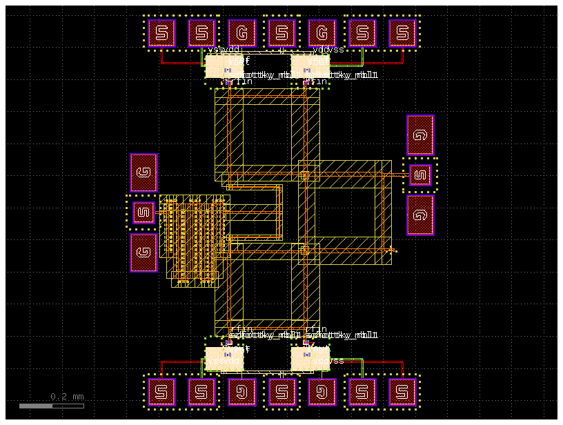

```python
pd4_ref = c.add_ref(pd).mirror_y()
pd4_ref.connect("rfin", rfin_connection_pd4.ports["e2"], allow_width_mismatch=True)

# vdd connection of pd4 to probe bottom
route_pd4_vdd = gf.routing.route_bundle_electrical(
    component=c,
    ports1=[pd4_ref.ports["vdd"]],
    ports2=[probe_bottom.ports["e4"]],
    route_width=8,    # adjust for thicker connections
    layer=ihp.tech.LAYER.TopMetal1drawing,
    start_straight_length=10,
    allow_layer_mismatch=True,
    allow_width_mismatch=True,
    auto_taper=False,
    separation=0,
)
# vss connection of pd4 to probe bottom
route_pd4_vss = gf.routing.route_bundle_electrical(
    component=c,
    ports1=[pd4_ref.ports["vss"]],
    ports2=[probe_bottom.ports["e3"]],
    route_width=2,    # adjust for thicker connections
    layer=ihp.tech.LAYER.Metal5drawing,
    start_straight_length=10, # 10 or longer, to avoid routing through itself
    allow_layer_mismatch=True,
    allow_width_mismatch=True,
    auto_taper=False,
    separation=0,
)
# vout connection of pd4 to probe bottom
via_M4_TM1_ref = c.add_ref(via_M4_TM1)
via_M4_TM1_ref.connect("top", probe_bottom.ports["e2"], allow_width_mismatch=True, allow_layer_mismatch=True)
via_M4_TM1_ref.move((0, -via_M4_TM1_ref.ysize/2))
route_pd4_vout = gf.routing.route_bundle_electrical(
    component=c,
    ports1=[pd4_ref.ports["vout"]],
    ports2=[via_M4_TM1_ref.ports["bottom"]],
    route_width=4,    # adjust for thicker connections
    layer=ihp.tech.LAYER.Metal4drawing,
    start_straight_length=10, # 10 or longer, to avoid routing through itself
    allow_layer_mismatch=True,
    allow_width_mismatch=True,
    auto_taper=False,
    separation=0,
)
# vref connection of pd4 to probe bottom
via_M3_TM1_ref = c.add_ref(via_M3_TM1)
via_M3_TM1_ref.connect("top", probe_bottom.ports["e1"], allow_width_mismatch=True, allow_layer_mismatch=True)
via_M3_TM1_ref.move((0, -via_M3_TM1_ref.ysize/2))
route_pd4_vref = gf.routing.route_bundle_electrical(
    component=c,
    ports1=[pd4_ref.ports["vref"]],
    ports2=[via_M3_TM1_ref.ports["bottom"]],
    route_width=4,    # adjust for thicker connections
    layer=ihp.tech.LAYER.Metal3drawing,
    start_straight_length=10, # 10 or longer, to avoid routing through itself
    allow_layer_mismatch=True,
    allow_width_mismatch=True,
    auto_taper=False,
    separation=0,
)

c.plot()
```

## Place Sealring

After the six-port is assembled, it is important to place a sealring around it. The sealring is necessary at the chip edge to stop cracks from spreading during the dicing process. It also works as a metal barrier to block moisture and chemicals from entering the internal layers. This ensures the long-term reliability and prevents corrosion of the semiconductor die.

The code cell sizes the sealring from the extent of the chip so far, with a margin of `SEALRING_MARGIN` = 50 µm on the left and right side and 25 µm at the top and bottom, and centers it on the chip. The inner edge of the sealring, on the layer `EdgeSealboundary`, is the reference for the metal fill below.

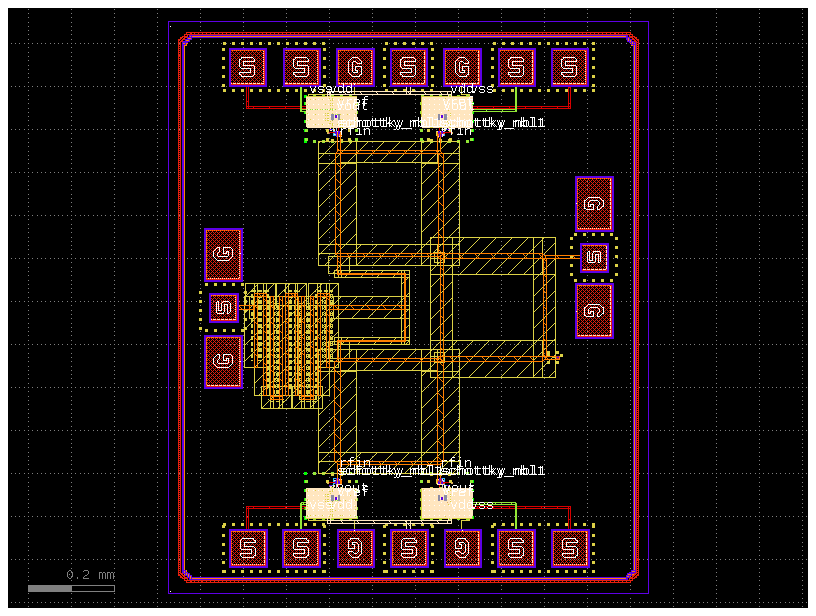

```python
sealring_margin = SEALRING_MARGIN  # margin around circuit for sealring
sealring_width = round(c.xsize + 2 * sealring_margin)
sealring_height = round(c.ysize + 2 * sealring_margin / 2)

sealring_center = (round(c.center[0], 2), round(c.center[1], 2))  # round it to avoid off grid errors
c.add_ref(ihp.cells.sealring(width=sealring_width, height=sealring_height)).center = sealring_center

c.plot()
```

## Define Metal Fill Patterns

Define helper functions for creating metal fill cells:

- **`fill_cell()`**: Generic rectangular fill cell of a given size on the specified layer
- **`fill_gat_active()`**: GatPoly filler with a centered, inset Activ filler for gate and active region filling
- **`fill_ground()`**: 1×1 µm Metal5 ground plane fill cell
- **`slit_ground()`**: Metal5 slit pattern for the ground plane

These fill cells are used by gdsfactory's `fill()` function to uniformly distribute metal and maintain electrical properties.

```python
@gf.cell
def fill_cell(layer=ihp.tech.LAYER.Metal5slit, size=(3, 3)) -> gf.Component:
    """Simple rectangular fill cell for a given layer and size."""
    c = gf.Component()
    c << gf.c.rectangle(layer=layer, size=size)
    return c


@gf.cell
def fill_gat_active(size=(3, 3), active_extension=(0.18, 0.18)) -> gf.Component:
    """Gate-poly + active filler cell with centred Activ region.

    `size` sets GatPoly:filler directly (bounded by GFil.a's 5.00um max width);
    Activ:filler is inset by `active_extension` so GatPoly:filler encloses it (GFil.j).
    """
    c = gf.Component()
    gat_ref = c.add_ref(gf.c.rectangle(layer=ihp.tech.LAYER.GatPolyfiller, size=size))
    activ_ref = c.add_ref(
        gf.c.rectangle(
            layer=ihp.tech.LAYER.Activfiller,
            size=(size[0] - 2 * active_extension[0], size[1] - 2 * active_extension[1]),
        )
    )
    activ_ref.center = gat_ref.center
    return c


@gf.cell
def fill_ground() -> gf.Component:
    """1 x 1 um Metal5 ground fill tile."""
    c = gf.Component()
    c.add_polygon(
        layer=ihp.tech.LAYER.Metal5drawing,
        points=[
            (0, 0),
            (1, 0),
            (1, 1),
            (0, 1),
        ],
    )
    return c


@gf.cell
def slit_ground() -> gf.Component:
    """Metal5 slit opening for ground fill."""
    c = gf.Component()
    c.add_polygon(
        layer=ihp.tech.LAYER.Metal5slit,
        points=[
            (1.1, 1.1),
            (4, 1.1),
            (4, 4.1),
            (1.1, 4.1),
        ],
    )
    return c
```

## Fill All Metal Layers

The metal fill keeps the density of every layer within the limits of the design rules, which the chemical-mechanical polishing (CMP) needs for flat layers. `c.fill()` places copies of a fill cell on a regular grid inside the seal boundary, minus the exclusion zones around existing structures:

| Layer | Fill cell | Spacing | Distance to the seal boundary | Kept away from |
| --- | --- | --- | --- | --- |
| GatPoly and Activ | 5 µm x 5 µm GatPoly filler with an Activ filler inset by 0.18 µm | 0.85 µm | 30 µm | devices (Activ, implants, wells, GatPoly, contacts) by 1.1 µm to 2 µm, pad openings by 12 µm |
| Metal1 and Metal2 | 5 µm x 5 µm | 1.1 µm | 40 µm | drawn metal and pad openings by 10 µm |
| Metal3 and Metal4 | 5 µm x 5 µm | 1 µm | 40 µm | drawn metal and pad openings by 10 µm |
| Metal5 | solid ground plane of 1 µm x 1 µm tiles, then slits of 2.9 µm x 3 µm | 0 µm, slits 1.1 µm x 1.2 µm | 50 µm | pad openings and Metal5 no-fill regions, slits 5 µm away from TopMetal2 lines and 1 µm from MIM capacitors |
| TopMetal1 | 30 µm x 30 µm drawn squares, then 10 µm x 10 µm filler | 1.65 µm, 3 µm | 10 µm | drawn TopMetal1 by 10 µm, TopMetal2 by 20 µm |

The Metal5 ground plane is the reference plane of all microstrip lines. The design rules require slits in wide metal, so slits are cut into it everywhere except under the TopMetal2 lines and the MIM capacitors. It stays 50 µm inside the seal boundary: any closer, it merges with the Metal5 ring of the sealring, which connects the whole sealring to VSS and adds antenna violations at the transistor gates tied to VSS.

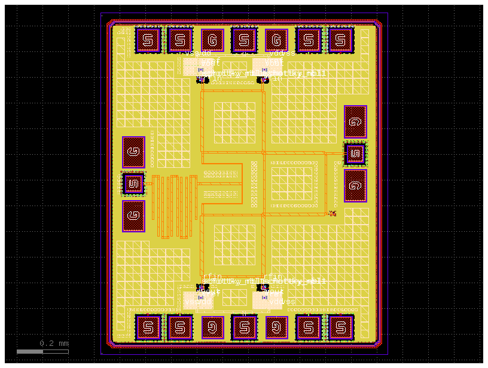

```python
# active/gat poly fill
gatpoly_activ_fill_space = 0.85
c.fill(
    fill_cell=fill_gat_active(size=(5, 5)),
    fill_layers=[(ihp.tech.LAYER.EdgeSealboundary, -30)],
    exclude_layers=[
        (ihp.tech.LAYER.Activdrawing, 1.1),
        (ihp.tech.LAYER.pSDdrawing, 1.1),
        (ihp.tech.LAYER.nSDblock, 1.1),
        (ihp.tech.LAYER.SalBlockdrawing, 1.1),
        (ihp.tech.LAYER.NWelldrawing, 1.1),
        (ihp.tech.LAYER.nBuLaydrawing, 1.1),
        (ihp.tech.LAYER.PWellblock, 1.5),
        (ihp.tech.LAYER.GatPolydrawing, 2),
        (ihp.tech.LAYER.Contdrawing, 1.2),
        (ihp.tech.LAYER.Passivdrawing, 12),
        (ihp.tech.LAYER.GatPolynofill, 1),
        (ihp.tech.LAYER.Activnofill, 1),
    ],
    x_space=gatpoly_activ_fill_space,
    y_space=gatpoly_activ_fill_space,
)
# metal1 fill
metal_fill_space = 1.1
c.fill(
    fill_cell=fill_cell(layer=ihp.tech.LAYER.Metal1filler, size=(5, 5)),
    fill_layers=[(ihp.tech.LAYER.EdgeSealboundary, -40)],
    exclude_layers=[
        (ihp.tech.LAYER.Metal1drawing, 10),
        (ihp.tech.LAYER.Passivdrawing, 10),
        (ihp.tech.LAYER.Metal1nofill, 1),
    ],
    x_space=metal_fill_space,
    y_space=metal_fill_space,
)
# metal2 fill
c.fill(
    fill_cell=fill_cell(layer=ihp.tech.LAYER.Metal2filler, size=(5, 5)),
    fill_layers=[(ihp.tech.LAYER.EdgeSealboundary, -40)],
    exclude_layers=[
        (ihp.tech.LAYER.Metal2drawing, 10),
        (ihp.tech.LAYER.Passivdrawing, 10),
        (ihp.tech.LAYER.Metal2nofill, 1),
    ],
    x_space=metal_fill_space,
    y_space=metal_fill_space,
)
# metal3 fill
metal_fill_space = 1
c.fill(
    fill_cell=fill_cell(layer=ihp.tech.LAYER.Metal3filler, size=(5, 5)),
    fill_layers=[(ihp.tech.LAYER.EdgeSealboundary, -40)],
    exclude_layers=[
        (ihp.tech.LAYER.Metal3drawing, 10),
        (ihp.tech.LAYER.Passivdrawing, 10),
        (ihp.tech.LAYER.Metal3nofill, 1),
    ],
    x_space=metal_fill_space,
    y_space=metal_fill_space,
)
# metal4 fill
c.fill(
    fill_cell=fill_cell(layer=ihp.tech.LAYER.Metal4filler, size=(5, 5)),
    fill_layers=[(ihp.tech.LAYER.EdgeSealboundary, -40)],
    exclude_layers=[
        (ihp.tech.LAYER.Metal4drawing, 10),
        (ihp.tech.LAYER.Passivdrawing, 10),
        (ihp.tech.LAYER.Metal4nofill, 1),
    ],
    x_space=metal_fill_space,
    y_space=metal_fill_space,
)
# metal5 fill (groundplate)
c.fill(
    fill_cell=fill_ground(),
    fill_layers=[(ihp.tech.LAYER.EdgeSealboundary, -50)],
    exclude_layers=[(ihp.tech.LAYER.Passivdrawing, 0), (ihp.tech.LAYER.Metal5nofill, 0)],
    x_space=0,
    y_space=0,
)
c.fill(
    fill_cell=slit_ground(),
    fill_layers=[(ihp.tech.LAYER.Metal5drawing, -2)],
    exclude_layers=[
        (ihp.tech.LAYER.TopMetal2drawing, 5),
        (ihp.tech.LAYER.MIMdrawing, 1),
        (ihp.tech.LAYER.Metal5slit, 1),
    ],
    x_space=1.1,
    y_space=1.2,
)
# topmetal1 fill
c.fill(
    fill_cell=fill_cell(layer=ihp.tech.LAYER.TopMetal1drawing, size=(30, 30)),
    fill_layers=[(ihp.tech.LAYER.EdgeSealboundary, -10)],
    exclude_layers=[(ihp.tech.LAYER.TopMetal1drawing, 10), (ihp.tech.LAYER.TopMetal2drawing, 20)],
    x_space=1.65,
    y_space=1.65,
)
c.fill(
    fill_cell=fill_cell(layer=ihp.tech.LAYER.TopMetal1filler, size=(10, 10)),
    fill_layers=[(ihp.tech.LAYER.EdgeSealboundary, -10)],
    exclude_layers=[(ihp.tech.LAYER.TopMetal1drawing, 10), (ihp.tech.LAYER.TopMetal2drawing, 20)],
    x_space=3,
    y_space=3,
)
c.plot()
```

## Add Logos and Decorative Elements

Import and place decorative logos for the chip. All positions are derived from the layout, so the logos follow the design frequency:

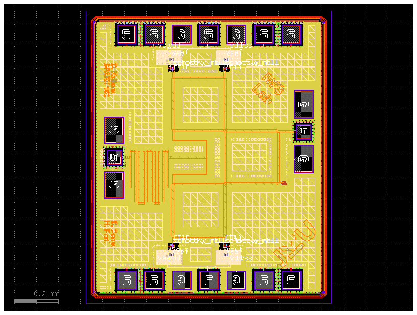

```python
logo_dir = Path("/tmp/assets")

logo_gds_path = logo_dir / "jku_logo_m5.gds"
kellerer_gds_path = logo_dir / "D_Kellerer.gds"
iws_gds_path = logo_dir / "IWS.gds"
supervisors_gds_path = logo_dir / "supervisors.gds"

# JKU logo in the lower right corner, relative to right chip edge, just above south pads
jku_logo_ref = c.add_ref(gf.import_gds(str(logo_gds_path), cellname="JKU_LOGO"))
chip_right = sealring_center[0] + sealring_width / 2
jku_logo_ref.xmax = chip_right - sealring_margin
jku_logo_ref.ymin = probe_bottom.ymax + 10

# place IWS logo only up to 200 GHz, to avoid overcrowding the layout for higher frequencies where the design is more compact
if f <= 200e9:
    iws = c.add_ref(gf.import_gds(str(iws_gds_path), cellname="Logo_IWS"))
    iws.xmax = blc_3_ref.xmax  # align right edge of IWS logo with right edge of BLC block
    iws.ymax = blc_1_ref.ymax  # align top edge of IWS logo with top edge of BLC block

# place gds with D. Kellerer only if space is available between top probe pads and left probe pads
kellerer = gf.import_gds(str(kellerer_gds_path), cellname="Name_D").rotate(-90)
if abs(probe_top.ymin - probe_left.ymax) > kellerer.ysize + 2 * LOGO_VERTICAL_CLEARANCE:
    kellerer_ref = c.add_ref(kellerer)
    kellerer_ref.xmin = probe_left.xmin
    kellerer_ref.center = (kellerer_ref.center[0], probe_left.ymax + (abs(probe_top.ymin - probe_left.ymax) / 2))
    kellerer_ref.xmin = snap_to_grid(kellerer_ref.xmin)
    kellerer_ref.ymin = snap_to_grid(kellerer_ref.ymin)

# place supervisor names only if space is available between bottom probe pads and left probe pads
supervisors = gf.import_gds(str(supervisors_gds_path), cellname="supervisors").rotate(-90)
if abs(probe_bottom.ymax - probe_left.ymin) > supervisors.ysize + 2 * LOGO_VERTICAL_CLEARANCE:
    supervisors_ref = c.add_ref(supervisors)
    supervisors_ref.xmin = probe_left.xmin
    supervisors_ref.center = (supervisors_ref.center[0], probe_bottom.ymax + (abs(probe_bottom.ymax - probe_left.ymin) / 2))
    supervisors_ref.xmin = snap_to_grid(supervisors_ref.xmin)
    supervisors_ref.ymin = snap_to_grid(supervisors_ref.ymin)

c.plot()
```

## Final TopMetal2 Fill and Chip Visualization

The TopMetal2 fill pattern is applied to complete the metal density requirements. Use 9×9µm fill cells with 3µm spacing, excluding the 20µm perimeter around TopMetal2 drawing layers. Plot the final complete chip design to visualize the finished layout with all components, routing, logos, and metal fill in place.

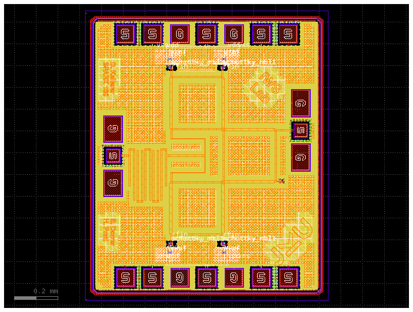

```python
c.fill(
        fill_cell=fill_cell(layer=ihp.tech.LAYER.TopMetal2filler, size=(9, 9)),
        fill_layers=[(ihp.tech.LAYER.EdgeSealboundary, -50)],
        exclude_layers=[(ihp.tech.LAYER.TopMetal2drawing, 20)],
        x_space=3,
        y_space=3,
    )
c.plot()
```

## Pad Labels and Pins

Finally, the chip is moved to its final origin, and every probe pad and bondpad gets a text label and a pin rectangle on its own metal layer. The labels name the pad nets (`vlo`, `vrf`, `vdd`, `vss`, `vout1`–`vout4`, `vref1`–`vref4`) for LVS and for identifying the pads in the layout viewer.

`bondpad_array` places the ports at the outer edge of each pad, so `add_pad_pin()` first moves the port to the pad center, then adds a text label on the text datatype (25) and a pin rectangle on the pin datatype (2) of the metal layer of the pad.

```python
def add_pad_pin(c: gf.Component, port_name: str, pad_name: str, pad_length: float ) -> None:
    """Add a port label and pin rectangle centered on a probe pad.

    Ports on pad arrays sit at the pad's outer edge rather than its
    center (see bondpad_array), offset by half the pad size in the
    direction the port faces. This recenters the label/pin on the pad
    before adding it, based on the port's orientation.

    Args:
        c: Parent component (`c`) that owns the port.
        port_name: Name of the port on `c` to label.
        pad_name: Text to use for the port label (e.g. "VOUT"). The text
            and pin layers are derived from the port's own drawing layer.
    """
    port = c.ports[port_name].copy()
    orientation = port.orientation % 360

    if orientation == 0:
        port.center = (port.center[0] - pad_length / 2, port.center[1])
    elif orientation == 90:
        port.center = (port.center[0], port.center[1] - pad_length / 2)
    elif orientation == 180:
        port.center = (port.center[0] + pad_length / 2, port.center[1])
    elif orientation == 270:
        port.center = (port.center[0], port.center[1] + pad_length / 2)
    else:
        raise ValueError(f"Unsupported port orientation: {port.orientation}")

    layer_number, _ = gf.get_layer_tuple(port.layer)
    text_layer = (layer_number, 25)
    pin_layer = (layer_number, 2)

    gf.labels.add_port_labels(c, ports=[port], layer=text_layer, texts=[pad_name])
    gf.add_pins.add_pin_rectangle(c, port=port, layer=pin_layer)


c.xmin = 0
c.ymin = 0
c.move((-25, -25))


# add port labels for probe pads on the left side of the chip
add_pad_pin(c = c, port_name="probe_left_e1", pad_name="vlo", pad_length=PROBE_SIGNAL_SIZE)
add_pad_pin(c = c, port_name="probe_left_e2", pad_name="vss", pad_length=PROBE_SIGNAL_SIZE)
add_pad_pin(c = c, port_name="probe_left_e3", pad_name="vss", pad_length=PROBE_SIGNAL_SIZE)

# add port labels for probe pads on the right side of the chip
add_pad_pin(c = c, port_name="probe_right_e1", pad_name="vrf", pad_length=PROBE_SIGNAL_SIZE)
add_pad_pin(c = c, port_name="probe_right_e2", pad_name="vss", pad_length=PROBE_SIGNAL_SIZE)
add_pad_pin(c = c, port_name="probe_right_e3", pad_name="vss", pad_length=PROBE_SIGNAL_SIZE)

# add port labels for probe pads on the top side of the chip
PROBE_SIGNAL_SIZE_TOP_BOTTOM = c.ports["probe_top_e1"].width  # size of the probe signal pads in um
add_pad_pin(c = c, port_name="probe_top_e1", pad_name="vref1", pad_length=PROBE_SIGNAL_SIZE_TOP_BOTTOM)
add_pad_pin(c = c, port_name="probe_top_e2", pad_name="vout1", pad_length=PROBE_SIGNAL_SIZE_TOP_BOTTOM)
add_pad_pin(c = c, port_name="probe_top_e3", pad_name="vss", pad_length=PROBE_SIGNAL_SIZE_TOP_BOTTOM)
add_pad_pin(c = c, port_name="probe_top_e4", pad_name="vdd", pad_length=PROBE_SIGNAL_SIZE_TOP_BOTTOM)
add_pad_pin(c = c, port_name="probe_top_e5", pad_name="vss", pad_length=PROBE_SIGNAL_SIZE_TOP_BOTTOM)
add_pad_pin(c = c, port_name="probe_top_e6", pad_name="vout2", pad_length=PROBE_SIGNAL_SIZE_TOP_BOTTOM)
add_pad_pin(c = c, port_name="probe_top_e7", pad_name="vref2", pad_length=PROBE_SIGNAL_SIZE_TOP_BOTTOM)

# add port labels for probe pads on the bottom side of the chip
add_pad_pin(c = c, port_name="probe_bottom_e1", pad_name="vref4", pad_length=PROBE_SIGNAL_SIZE_TOP_BOTTOM)
add_pad_pin(c = c, port_name="probe_bottom_e2", pad_name="vout4", pad_length=PROBE_SIGNAL_SIZE_TOP_BOTTOM)
add_pad_pin(c = c, port_name="probe_bottom_e3", pad_name="vss", pad_length=PROBE_SIGNAL_SIZE_TOP_BOTTOM)
add_pad_pin(c = c, port_name="probe_bottom_e4", pad_name="vdd", pad_length=PROBE_SIGNAL_SIZE_TOP_BOTTOM)
add_pad_pin(c = c, port_name="probe_bottom_e5", pad_name="vss", pad_length=PROBE_SIGNAL_SIZE_TOP_BOTTOM)
add_pad_pin(c = c, port_name="probe_bottom_e6", pad_name="vout3", pad_length=PROBE_SIGNAL_SIZE_TOP_BOTTOM)
add_pad_pin(c = c, port_name="probe_bottom_e7", pad_name="vref3", pad_length=PROBE_SIGNAL_SIZE_TOP_BOTTOM)
```

# Export Final GDS

The finished chip is written to `sparx_top.gds` without GDSFactory metadata, and on Colab the file is downloaded to the local machine. At `f` = 160 GHz, it is geometrically identical to `layout/sparx160_top.gds` of the SPARX repository, which `scripts/six_port_gen.py` generates.

```python
c.write_gds("sparx_top.gds", with_metadata=False)

# on Google Colab, download the GDS to the local machine
try:
    from google.colab import files
    files.download("sparx_top.gds")
except ImportError:
    pass
```

# Design Rule Check (DRC)

Finally, the generated layout is checked with the KLayout DRC decks of the IHP-Open-PDK. The decks are Ruby DRC scripts, so the full KLayout program is required in addition to the `klayout` Python module installed with GDSFactory.

**Installation of KLayout:**

The KLayout package matching the Ubuntu version of the runtime is downloaded from the KLayout website and installed with `apt`.

```python
import platform

KLAYOUT_VERSION = "0.30.12"
UBUNTU = platform.freedesktop_os_release()["VERSION_ID"].split(".")[0]

! wget -q https://www.klayout.org/downloads/Ubuntu-{UBUNTU}/klayout_{KLAYOUT_VERSION}-1_amd64.deb -O /tmp/klayout.deb
! apt-get update -qq > /dev/null 2>&1; apt-get install -y -qq /tmp/klayout.deb > /dev/null
assert shutil.which("klayout"), "KLayout was not installed, see the apt output above"
! klayout -b -v
```

```
KLayout 0.30.12
```

**Run DRC:**

The DRC is run with the `run_drc.py` wrapper of the IHP-Open-PDK. Three levels are available:

- `precheck`: minimal rule set of the foundry precheck. Fastest option.
- `macro`: all rules except chip-level density, antenna, and the extra rules. This is the level of `make klayout-drc` in the SPARX repository. The 160 GHz layout is clean, and so are the layouts of the other twelve frequencies the generator produces from 60 GHz to 300 GHz.
- `regular`: all rules, including density and antenna. The antenna violations reported at this level were waived by IHP for the tapeout, see KNOWN_ISSUES.md.

```python
import time

DRC_LEVEL = "regular"  # precheck, macro, or regular
DRC_DIR   = f"drc_{DRC_LEVEL}"
DRC_FLAGS = {
    "precheck": "--precheck_drc --no_density --no_offgrid --no_angle --disable_extra_rules --no_recommended",
    "macro":    "--no_density --disable_extra_rules",
    "regular":  "--antenna",
}[DRC_LEVEL]

# the rule deck is split into one part per physical CPU core, hyperthreads of the same core do not help because every part reloads the layout
DRC_CORES = len({open(f"/sys/devices/system/cpu/cpu{cpu}/topology/thread_siblings_list").read() for cpu in os.sched_getaffinity(0)})

start = time.time()
# the full logs are written to DRC_DIR, only a rule counter, the progress per rule table, and the result are shown here
! rm -rf {DRC_DIR} && python3 {PDK_ROOT}/ihp-sg13g2/libs.tech/klayout/tech/drc/run_drc.py --path=sparx_top.gds --topcell=Six-Port-CAC --run_dir={DRC_DIR} --mp={DRC_CORES} {DRC_FLAGS} 2>&1 \
    | awk '/Executing rule/ {{ if (++n % 50 == 0) print n " rules checked" }} /completed in|Check Passed|Check Failed|Violated rules|Total DRC Run time|ERROR/ {{ print }} {{ fflush() }}'
print(f"DRC ({DRC_LEVEL}) finished in {(time.time() - start) / 60:.1f} min")
```

```
2026-10-19 14:49:34 +0000: Memory Usage (461200K) : KLayout DRC run for tables 'cont' completed in 0.85 seconds
2026-10-19 14:49:37 +0000: Memory Usage (455476K) : KLayout DRC run for tables 'thickgateox' completed in 0.42 seconds
2026-10-19 14:49:40 +0000: Memory Usage (460260K) : KLayout DRC run for tables 'contbar' completed in 0.74 seconds
2026-10-19 14:49:42 +0000: Memory Usage (457668K) : KLayout DRC run for tables 'psd' completed in 0.46 seconds
2026-10-19 14:50:13 +0000: Memory Usage (1209156K) : KLayout DRC run for tables 'nbulay' completed in 28.89 seconds
2026-10-19 14:50:17 +0000: Memory Usage (457428K) : KLayout DRC run for tables 'pwellblock' completed in 0.66 seconds
2026-10-19 14:50:20 +0000: Memory Usage (460684K) : KLayout DRC run for tables 'gatpolyfiller' completed in 0.64 seconds
50 rules checked
2026-10-19 14:50:51 +0000: Memory Usage (1208996K) : KLayout DRC run for tables 'nwell' completed in 28.8 seconds
```

```
2026-10-19 14:50:55 +0000: Memory Usage (458704K) : KLayout DRC run for tables 'schottkydiode' completed in 0.82 seconds
2026-10-19 14:50:57 +0000: Memory Usage (462972K) : KLayout DRC run for tables 'activfiller' completed in 0.71 seconds
2026-10-19 14:51:00 +0000: Memory Usage (455668K) : KLayout DRC run for tables 'npnsubstratetie' completed in 0.55 seconds
2026-10-19 14:51:03 +0000: Memory Usage (460144K) : KLayout DRC run for tables 'gatpoly' completed in 0.82 seconds
2026-10-19 14:51:06 +0000: Memory Usage (456304K) : KLayout DRC run for tables 'latchup' completed in 0.93 seconds
2026-10-19 14:51:08 +0000: Memory Usage (457944K) : KLayout DRC run for tables 'activ' completed in 0.67 seconds
2026-10-19 14:51:11 +0000: Memory Usage (452404K) : KLayout DRC run for tables 'metalslits' completed in 0.61 seconds
2026-10-19 14:51:21 +0000: Memory Usage (480712K) : KLayout DRC run for tables 'sealring' completed in 7.86 seconds
100 rules checked
2026-10-19 14:51:23 +0000: Memory Usage (458048K) : KLayout DRC run for tables 'copperpillar' completed in 0.5 seconds
2026-10-19 14:51:26 +0000: Memory Usage (457868K) : KLayout DRC run for tables 'topmetal2filler' completed in 0.53 seconds
```

```
2026-10-19 14:51:28 +0000: Memory Usage (456260K) : KLayout DRC run for tables 'lbe' completed in 0.5 seconds
2026-10-19 14:51:31 +0000: Memory Usage (457412K) : KLayout DRC run for tables 'topmetal1filler' completed in 0.54 seconds
2026-10-19 14:51:34 +0000: Memory Usage (459352K) : KLayout DRC run for tables 'via1' completed in 0.62 seconds
2026-10-19 14:51:36 +0000: Memory Usage (455064K) : KLayout DRC run for tables 'solderbump' completed in 0.59 seconds
2026-10-19 14:51:39 +0000: Memory Usage (457208K) : KLayout DRC run for tables 'topvia1' completed in 0.58 seconds
150 rules checked
2026-10-19 14:51:42 +0000: Memory Usage (460024K) : KLayout DRC run for tables 'metal1' completed in 0.75 seconds
2026-10-19 14:51:44 +0000: Memory Usage (457428K) : KLayout DRC run for tables 'topmetal1' completed in 0.45 seconds
2026-10-19 14:51:47 +0000: Memory Usage (458832K) : KLayout DRC run for tables 'topmetal2' completed in 0.56 seconds
```

```
2026-10-19 14:51:49 +0000: Memory Usage (457860K) : KLayout DRC run for tables 'passiv' completed in 0.5 seconds
2026-10-19 14:51:52 +0000: Memory Usage (449804K) : KLayout DRC run for tables 'topvia2' completed in 0.81 seconds
2026-10-19 14:52:11 +0000: Memory Usage (1446456K) : KLayout DRC run for density table completed in 157.21 seconds
2026-10-19 14:52:12 +0000: Memory Usage (818348K) : KLayout DRC run for tables 'pad' completed in 17.72 seconds
2026-10-19 14:52:14 +0000: Memory Usage (460560K) : KLayout DRC run for tables 'mim' completed in 0.69 seconds
200 rules checked
2026-10-19 14:52:18 +0000: Memory Usage (451332K) : KLayout DRC run for tables 'vian' completed in 1.73 seconds
2026-10-19 14:52:23 +0000: Memory Usage (447488K) : KLayout DRC run for tables 'forbidden' completed in 1.02 seconds
250 rules checked
2026-10-19 14:52:27 +0000: Memory Usage (1085020K) : KLayout DRC run for tables 'metaln' completed in 50.52 seconds
300 rules checked
2026-10-19 14:52:28 +0000: Memory Usage (2375008K) : KLayout DRC run for maximum ruleSet completed in 174.13 seconds
2026-10-19 14:52:28 +0000: Memory Usage (460264K) : KLayout DRC run for tables 'metalnfiller' completed in 14.33 seconds
```

```
350 rules checked
2026-10-19 14:52:30 +0000: Memory Usage (456148K) : KLayout DRC run for tables 'pin' completed in 0.52 seconds
400 rules checked
450 rules checked
500 rules checked
550 rules checked
600 rules checked
2026-10-19 14:53:06 +0000: Memory Usage (905576K) : KLayout DRC run for tables 'offgrid' completed in 36.34 seconds
2026-10-19 14:53:30 +0000: Memory Usage (1077904K) : KLayout DRC run for tables 'angle' completed in 64.67 seconds
19-Oct-2026 14:53:30 | ERROR   | ==================================================================================
19-Oct-2026 14:53:30 | ERROR   | ❌ --- KLayout DRC Check Failed: Violations were detected in the layout. --- ❌
19-Oct-2026 14:53:30 | ERROR   | ==================================================================================
19-Oct-2026 14:53:30 | ERROR   | Violated rules are : {'Ant.h', 'Ant.e_TopMetal2', 'Ant.e_TopMetal1', 'Ant.e_Metal5', 'Ant.f_TopVia2'}
19-Oct-2026 14:53:30 | INFO    | Total DRC Run time: 238.46 seconds (including execution, analysis, and reporting)
```

```
DRC (regular) finished in 4.0 min
```

**DRC Summary:**

The violations are counted per rule from the KLayout result databases (`.lyrdb`), which can also be opened in the KLayout marker browser.

```python
import glob
import xml.etree.ElementTree as ET
from collections import Counter

# every <item> in a result database is one violation, its <category> is the rule name
lyrdbs = glob.glob(f"{DRC_DIR}/*.lyrdb")
assert lyrdbs, f"No DRC result in {DRC_DIR}, the DRC did not run, see the output above"
violations = Counter()
for lyrdb in lyrdbs:
    for item in ET.parse(lyrdb).getroot().iterfind("./items/item"):
        violations[item.findtext("category").strip("'")] += 1

for rule, count in sorted(violations.items()):
    print(f"{rule:<24} {count:>6}")
print(f"DRC ({DRC_LEVEL}): {sum(violations.values())} violations in {len(violations)} rules")
```

```
Ant.e_Metal5                  8
Ant.e_TopMetal1               8
Ant.e_TopMetal2               8
Ant.f_TopVia2                 8
Ant.h                         1
DRC (regular): 33 violations in 5 rules
```

# Circuit Simulation with VACASK

The passive RF structures of SPARX were simulated with the EM solver AWS Palace, and the power detector was designed in Xschem. The following cells take this flow to the circuit level with VACASK, an open-source analog simulator with harmonic balance (HB), periodic steady state (PSS), and the periodic small-signal analyses HBAC, HBNOISE, PAC, and PNOISE. Most open-source RFIC work uses Qucs-S and Xyce, which was long the only open-source SPICE-compatible simulator with HB, but offers neither PSS nor HBAC nor transient noise. VACASK provides all of them, a shooting PSS, the quasi-periodic HBAC on top of an HB solution, and device-level transient noise, and since September 2026 also HBNOISE around an HB solution and PAC and PNOISE around a shooting PSS, which is what makes the large-signal characterization of a pumped detector possible in an open-source flow:

1. The EM result of the six-port core is converted into a lumped-element netlist with `snp2le`, which carries the thermal noise of the core by Bosma's theorem.
2. The power detector is characterized: transfer curve (HB and PSS), noise figure (HBAC and HBNOISE, checked with PAC and PNOISE), and transient noise.
3. The receiver, the six-port core driving the four post-layout power detectors, is simulated with HB, HBAC, and a transient.
4. The noise figure of the receiver is simulated through the core model, with HBAC and HBNOISE, checked with PAC and PNOISE.

The testbenches are the ones of the SPARX repository, where each result is explained in detail in the [testbench README](https://github.com/iic-jku/SG13CMOS_SPARX/blob/next_release/testbenches/xschem/README.md). Their netlists were exported from the Xschem schematics and are fetched from the repository together with the post-processing scripts.

> **Important:** The simulations use the 160 GHz design of the SPARX repository. The EM result of the six-port core (`sparx160_core.s7p`), the post-layout extraction of the power detector, and the LO and RF frequencies of the testbenches do not follow the frequency `f` set above. For a layout generated at another frequency, the EM simulation of the new layout with AWS Palace and the extraction have to be redone in the repository flow first, which is beyond the scope of this notebook.

> **Note:** Every cell of this section has a `RUN_...` flag at its top, set it to `0` to skip the cell. The transient-noise simulation and the two receiver simulations are switched off by default because of their runtime, set their flags to `1` to run them. The noise-figure simulation reads the responsivity of the transfer-curve simulation, and the transient-noise simulation reads the result of the noise-figure simulation, so run them in this order.

**Installation of VACASK:**

The periodic analyses PAC and PNOISE reached VACASK at the end of September 2026, and IIC-OSIC-TOOLS ships them since its 2026.10 image, with VACASK `fb8cc20`. Its VACASK and OpenVAF-Reloaded image layers are downloaded from Docker Hub, verified against their digest, and unpacked to the paths of the image. With `BUILD_VACASK = 1`, the same VACASK commit is built from source instead, which takes about 12 minutes.

VACASK reads the device models of the IHP-Open-PDK as its own model libraries, and those are generated from the ngspice models of the PDK by the `sg13g2tovc` converter shipped with VACASK. Before the conversion, the fixes that IIC-OSIC-TOOLS applies to this converter for its image are applied as well. They add the model files and Verilog-A models of the PDK that the converter does not list, so the model libraries match those of the 2026.10 image. Finally, the testbenches, their netlists, and the post-processing scripts are fetched from the SPARX repository.

> **Runtime:** On the two vCPUs of the free Colab tier, this cell takes about **1 minute**.

```python
import hashlib
import json
import re
import subprocess

RUN_VACASK_INSTALL = 1  # 1 = run this cell, 0 = skip it
BUILD_VACASK       = 0  # 1 = build VACASK from source, 0 = download the IIC-OSIC-TOOLS build

# VACASK (with pac and pnoise) and OpenVAF-Reloaded of the IIC-OSIC-TOOLS 2026.10 image, one image layer each
IIC_IMAGE     = "hpretl/iic-osic-tools"
IIC_LAYERS    = {
    "vacask":  "sha256:12b2b9dbcb0b0465bfbcd7f0143c98d7e8ab376b401f760c9901da33bf3a0976",
    "openvaf": "sha256:cf84ea92ff0036047cff9aa2fcf2937355fe190427a63bffdcb8fc8308676ea9",
}
VACASK_COMMIT = "fb8cc2055a4f10cff1de8017b554d22ea57ce448"  # the VACASK commit of the 2026.10 image
IIC_COMMIT    = "68d3f07e6eeb9ded2cf79d4db9ca9d574862db02"  # the 2026.10 tag of IIC-OSIC-TOOLS, for its fixes of the model converter
IIC_FIXES     = ["fix_sg13g2_vacask_converter.py", "fix_vacask_swsoa.py", "fix_sg13g2_vacask_va.py"]
VACASK_DIR    = "/foss/tools/vacask"
OPENVAF_DIR   = "/foss/tools/openvaf"
SPARX_DIR     = "/tmp/sparx"  # sparse checkout of the SPARX repository
XSCHEM_DIR    = f"{SPARX_DIR}/testbenches/xschem"
SIM_DIR       = f"{XSCHEM_DIR}/simulations"
PLOT_DIR      = f"{XSCHEM_DIR}/plot_simulations"

if RUN_VACASK_INSTALL:
    start = time.time()
    if BUILD_VACASK:
        # the build recipe of IIC-OSIC-TOOLS: Boost 1.88 is built because Ubuntu 24.04 ships 1.83, OpenVAF-Reloaded compiles the built-in device models
        ! apt-get update -qq > /dev/null 2>&1; apt-get install -y -qq cmake ninja-build bison flex libfftw3-dev libsuperlu-dev libopenblas-dev liblapack-dev libsuitesparse-dev libtomlplusplus-dev libllvm18 > /dev/null
        ! mkdir -p {OPENVAF_DIR} && wget -qO- https://github.com/OpenVAF/OpenVAF-Reloaded/releases/download/v24.0.2mob/openvaf-r-v24.0.2mob-linux-x86_64.tar.gz | tar xz -C {OPENVAF_DIR} --strip-components=1
        ! cd /tmp && wget -q https://archives.boost.io/release/1.88.0/source/boost_1_88_0.tar.gz && tar xzf boost_1_88_0.tar.gz
        ! cd /tmp/boost_1_88_0 && ./bootstrap.sh --with-toolset=gcc > /tmp/boost_build.log 2>&1 && ./b2 -j{os.cpu_count()} --with-filesystem --with-process --with-asio link=static toolset=gcc define=BOOST_PROCESS_V2_DISABLE_PIDFD_OPEN cxxflags=-march=x86-64-v2 cflags=-march=x86-64-v2 >> /tmp/boost_build.log 2>&1 || tail -20 /tmp/boost_build.log
        ! rm -rf /tmp/vacask && git clone -q --filter=blob:none --no-checkout https://codeberg.org/arpadbuermen/VACASK.git /tmp/vacask && git -C /tmp/vacask checkout -q {VACASK_COMMIT}
        ! cmake -G Ninja -S /tmp/vacask -B /tmp/vacask/build -DCMAKE_BUILD_TYPE=Release -DCMAKE_CXX_FLAGS="-march=x86-64-v2 -DBOOST_PROCESS_V2_DISABLE_PIDFD_OPEN" -DCMAKE_C_FLAGS=-march=x86-64-v2 -DOPENVAF_OPTIONS="--target_cpu generic" -DOPENVAF_DIR={OPENVAF_DIR}/bin -DBoost_DIR=/tmp/boost_1_88_0/stage/lib/cmake/Boost-1.88.0 > /tmp/vacask_build.log 2>&1 || tail -20 /tmp/vacask_build.log
        ! cmake --build /tmp/vacask/build -j{os.cpu_count()} >> /tmp/vacask_build.log 2>&1 && cmake --install /tmp/vacask/build --prefix {VACASK_DIR} --strip >> /tmp/vacask_build.log 2>&1 || tail -20 /tmp/vacask_build.log
        ! rm -rf /tmp/boost_1_88_0 /tmp/boost_1_88_0.tar.gz /tmp/vacask
        # the post-processing scripts import rawfile, which VACASK ships as vacask.rawfile, the alias IIC-OSIC-TOOLS adds
        open(f"{VACASK_DIR}/lib/vacask/python/rawfile.py", "w").write("import sys\nimport vacask.rawfile\nsys.modules[__name__] = vacask.rawfile\n")
    else:
        # the layers are fetched from Docker Hub as `docker pull` would, and unpacked to the paths of the image
        token = json.load(urllib.request.urlopen(f"https://auth.docker.io/token?service=registry.docker.io&scope=repository:{IIC_IMAGE}:pull"))["token"]
        for name, digest in IIC_LAYERS.items():
            request = urllib.request.Request(f"https://registry-1.docker.io/v2/{IIC_IMAGE}/blobs/{digest}", headers={"Authorization": f"Bearer {token}"})
            layer = urllib.request.urlopen(request).read()
            assert "sha256:" + hashlib.sha256(layer).hexdigest() == digest, f"the {name} layer does not match its digest"
            open(f"/tmp/{name}.tar.gz", "wb").write(layer)
            ! tar xzf /tmp/{name}.tar.gz -C / && rm /tmp/{name}.tar.gz
        # the image build links against KLU, OpenBLAS, FFTW, and LLVM 18, which a plain Ubuntu 24.04 runtime lacks
        ! apt-get update -qq > /dev/null 2>&1; apt-get install -y -qq libklu2 libopenblas0 libfftw3-double3 libllvm18 > /dev/null

    # IIC-OSIC-TOOLS adapts the converter to the PDK before it runs it: model files and Verilog-A models of the PDK that the converter does not list
    converter = f"{VACASK_DIR}/lib/vacask/python/vacask/sg13g2tovc.py"
    for fix in IIC_FIXES:
        ! wget -qO /tmp/{fix} https://raw.githubusercontent.com/iic-jku/IIC-OSIC-TOOLS/{IIC_COMMIT}/_build/images/open_pdks/scripts/{fix} && python3 /tmp/{fix} {converter} {PDK_ROOT}/ihp-sg13g2 > /dev/null
    assert "fix_sg13g2_vacask_va.py" in open(converter).read(), "the converter fixes of IIC-OSIC-TOOLS were not applied"
    # the VACASK model libraries of the PDK are generated from its ngspice models, and its Verilog-A models are compiled to OSDI
    ! PYTHONPATH={VACASK_DIR}/lib/vacask/python OPENVAF_DIR={OPENVAF_DIR}/bin python3 -m vacask.sg13g2tovc --openvaf-options --target_cpu generic > /tmp/sg13g2tovc.log 2>&1 || tail -20 /tmp/sg13g2tovc.log
    assert os.path.exists(f"{PDK_ROOT}/ihp-sg13g2/libs.tech/vacask/osdi/psp103.osdi"), "the PDK models were not generated, see /tmp/sg13g2tovc.log"
    ! cp {VACASK_DIR}/share/doc/vacask/demo/ihp-sg13g2/.vacaskrc.toml ~/

    # testbench netlists, fitted passive models, post-layout extraction, EM results, and post-processing scripts
    ! rm -rf {SPARX_DIR} && git clone -q --depth 1 --filter=blob:none --sparse -b {SPARX_BRANCH} https://github.com/iic-jku/SG13CMOS_SPARX.git {SPARX_DIR} > /tmp/sparx_checkout.log 2>&1 || cat /tmp/sparx_checkout.log
    ! git -C {SPARX_DIR} sparse-checkout set testbenches/xschem netlist scripts verification/em/s-parameter >> /tmp/sparx_checkout.log 2>&1 || cat /tmp/sparx_checkout.log
    assert os.path.isdir(f"{XSCHEM_DIR}/netlists"), "the testbenches were not fetched from the SPARX repository"
    ! mkdir -p {SIM_DIR} && cp {XSCHEM_DIR}/netlists/* {SIM_DIR}/
    print(f"VACASK installed in {(time.time() - start) / 60:.1f} min")

# the post-processing scripts read the VACASK output with the rawfile module shipped with VACASK
os.environ["PATH"]       = f"{VACASK_DIR}/bin:{os.environ['PATH']}"
os.environ["PYTHONPATH"] = f"{VACASK_DIR}/lib/vacask/python"
version = subprocess.run(["vacask", "--version"], capture_output=True, text=True)
version = version.stdout + version.stderr
assert "This is vacask" in version, f"VACASK does not start:\n{version}"
print(version.splitlines()[0])


def run_testbench(tb, variant=""):
    """Simulate a testbench with VACASK and post-process it, as `make sim-xschem` does in the SPARX repository."""
    global RUN_START
    sim_dir = f"{SIM_DIR}/{variant}" if variant else SIM_DIR
    start = RUN_START = time.time()
    with open(f"{sim_dir}/{tb}.log", "w") as log:
        vacask = subprocess.run(["vacask", "-qp", "-sp", f"{tb}.spectre"], cwd=sim_dir, stdin=subprocess.DEVNULL, stdout=log, stderr=subprocess.STDOUT)
    print(f"{tb}: VACASK finished in {(time.time() - start) / 60:.1f} min")
    # VACASK exits with 0 even when an analysis aborts or is missing from the build, so its log is checked as well
    log = open(f"{sim_dir}/{tb}.log").read()
    if vacask.returncode or re.search("aborted|failed|not found", log, re.IGNORECASE):
        raise RuntimeError(f"VACASK failed, see {sim_dir}/{tb}.log:\n{log[-3000:]}")
    plot = subprocess.run(["python3", f"{PLOT_DIR}/plot_{tb}.py"], cwd=SPARX_DIR, env={**os.environ, "POWDET_VARIANT": variant}, capture_output=True, text=True)
    print(plot.stdout)
    if plot.returncode:
        raise RuntimeError(f"the post-processing of {tb} failed:\n{plot.stderr[-3000:]}")


def show_figure(name):
    """Display a figure of the post-processing, but only if the last run_testbench() has written it."""
    path = f"{PLOT_DIR}/figures/{name}"
    # the repository holds a committed copy of every figure, which must not pass for a new result
    assert os.path.getmtime(path) >= RUN_START, f"{name} was not written by this simulation"
    display(Image(filename=path, width=1024))
```

```
VACASK installed in 0.6 min
This is vacask fb8cc20.
```

**S-Parameters to Lumped-Element Netlist (snp2le):**

A circuit simulator cannot use the S-parameters of the EM simulation directly in harmonic balance or transient analyses. snp2le fits the 7-port S-parameters of the six-port core (BPF, WPD, and three BLCs in one EM solve) with a rational model of order 24, enforces passivity, and writes it as a VACASK subcircuit of resistors, capacitors, and controlled sources. The two receiver testbenches below include this subcircuit.

This step from the EM results back to circuit simulation has been the missing link of open-source RF flows, where EM-verified passives used to be approximated by hand-tuned lumped elements. The core can be modeled either by one fit of the complete 7-port EM result, as here, or by a composition of block fits of order 13 for the bandpass filter, 10 for the Wilkinson power divider, and 6 for each branch-line coupler. The composition converges better and simulates faster, but contains neither the coupling between adjacent couplers nor the interconnects, which is why the receiver uses the single fit.

**Thermal noise by Bosma's theorem:**

A lossy passive is a noise source, and at a uniform temperature its noise follows from its S-parameters alone. Every port $k$ of a noisy N-port emits a noise wave $c_k$ on top of the scattered signal, $\mathbf{b} = \mathbf{S}\,\mathbf{a} + \mathbf{c}$, with $\mathbf{a}$ and $\mathbf{b}$ the incident and outgoing power waves. [Bosma's theorem](https://doi.org/10.6100/IR109175) gives the correlation matrix of these noise waves for a linear passive N-port in thermal equilibrium at the temperature $T$,

$$\mathbf{C}_\mathrm{S} = kT\,(\mathbf{I} - \mathbf{S}\mathbf{S}^\mathrm{H}),$$

with the Boltzmann constant $k$, the identity matrix $\mathbf{I}$, and the conjugate transpose $\mathbf{S}^\mathrm{H}$ of the S-matrix. The diagonal entry $(\mathbf{C}_\mathrm{S})_{kk} = kT\,(1 - \sum_j |S_{kj}|^2)$ is the noise power per hertz that port $k$ sends into a matched load. In a reciprocal network such as this core, it is $kT$ times the share of the power entering port $k$ that the network dissipates. A lossless network is therefore noiseless, and a matched resistor emits the full $kT$. The off-diagonal entries correlate the noise of ports that see the same lossy elements. $\mathbf{C}_\mathrm{S}$ is a covariance and has to be positive semidefinite, which holds exactly when the largest singular value of $\mathbf{S}$ is at most one, so passivity and noise are one condition. For the EM result of the core at 160 GHz, the equation gives 0.69 $kT$ at the LO port, whose path runs through the BPF, the WPD, and a coupler, 0.29 $kT$ at the RF port, and 0.45 $kT$ to 0.55 $kT$ at the four outputs.

The resistors of a vector fit place its poles and do not model the loss of the structure, so snp2le emits them noiseless (`noisy=0`). With `--thermal-noise`, as in `make sparx-core` of the repository, it factors $\mathbf{I} - \mathbf{S}\mathbf{S}^\mathrm{H}$ of the fitted model into a noise generator, driven by one white source of density $kT$ per port, and appends it to the subcircuit without touching the signal network. VACASK sees this noise in `noise`, `hbnoise`, `pnoise`, and transient noise. The [documentation](https://iic-jku.github.io/SG13CMOS_SPARX/#sec-thermal-noise) discusses the theorem in more detail.

The fit is made from `sparx160_core.s7p`, the EM result without de-embedding, as for the fit in the repository, and the new fit replaces `netlist/spectre/sparx_core_le.inc` in the checkout. The result line reports the RMS error of the fit against the EM data, the number of poles, the largest singular value of the S-matrix (`sigma_max`, at most 1 for a passive model), and whether the DC operating point of the netlist can be solved.

```python
RUN_SNP2LE = 1  # 1 = run this cell, 0 = skip it (the receiver then uses the fit stored in the repository)

if RUN_SNP2LE:
    %pip install -q --progress-bar off snp2le==0.1.12 scikit-rf==2.1.0
    start = time.time()
    ! cd {SPARX_DIR} && QT_QPA_PLATFORM=offscreen snp2le -b convert verification/em/s-parameter/sparx160_core.s7p --mode universal --order 24 --format vacask --thermal-noise -o netlist/spectre/sparx_core_le.inc
    print(f"snp2le finished in {(time.time() - start) / 60:.1f} min")
    ! head -12 {SPARX_DIR}/netlist/spectre/sparx_core_le.inc
```

```
  sparx160_core.s7p [#######---------------]  31%  0.2 s  vector fitting, 11 it
```

```
  sparx160_core.s7p [#########-------------]  43%  0.4 s  enforcing passivity,
```

```
  sparx160_core.s7p [#############---------]  59%  1.1 s  measuring the passivi
```

```
[ OK ] verification/em/s-parameter/sparx160_core.s7p -> netlist/spectre/sparx_core_le.inc  (vacask, rms=3.86e-03  order=23 (12 poles)  sigma_max=1.000  dc=solvable  noise=thermal, 2.6 s)
       note: passivity enforced (n_samples=200, rms=3.86e-03)
```

```
snp2le finished in 0.1 min
```

```
// sparx_core_le - lumped-element equivalent (VACASK / Spectre), generated by snp2le
// EQUIVALENT CIRCUIT FOR VECTOR FITTED S-MATRIX
// Created using scikit-rf vectorFitting.py
//
//
// thermal noise of the passive: kT(I - S S^H) at the ports, from a spectral factor of this fit
// sources Rnz_e1..Rnz_e7 (0.25 ohm, the only noisy elements), 161 states nz_x*, controlled sources Gnz_*
// device models needed (declared by your testbench): capacitor, cccs, resistor, vccs, vsource
// NOTE: ground is 'GND'. Your testbench must declare it as the ground (Xschem's spectre netlist does this with `ground GND`), otherwise the circuit floats and the result is wrong.
subckt sparx_core_le (p1 p2 p3 p4 p5 p6 p7)
  V1 (p1 s1) vsource dc=0
  R1 (s1 GND) resistor r=50 noisy=0
```

**snp2le Result:**

The fit reaches an RMS error of 3.9e-3 with 12 poles, is passive (`sigma_max = 1.000`) and carries the thermal noise of the core (`noise=thermal`). It reproduces the fit committed in the repository. Resimulated with VACASK in the repository testbench `sparx_core_le_tb_acsp_vacask`, it matches the EM S-parameters at 160 GHz within 0.45 dB and 9.9 degrees across all 49 S-parameters. Both extremes fall on one output-to-output coupling at -35 dB, every other S-parameter is within 0.36 dB and 5 degrees, see [section 1 of the testbench README](https://github.com/iic-jku/SG13CMOS_SPARX/blob/next_release/testbenches/xschem/README.md#1-passive-models-s-parameters).

**Power Detector: Transfer Curve and Input Impedance (HB and PSS):**

The power detector is a forward-biased Schottky barrier diode feeding a transimpedance amplifier, with a replica branch for a differential readout. At the tapeout in March 2026, the detector was checked with a two-tone HB sweep in VACASK, which confirmed square-law detection, an IF output proportional to the product of the RF and the LO amplitude, and nothing beyond. The PSS, HBAC, HBNOISE, PAC, PNOISE, and transient-noise analyses added to VACASK later in 2026 characterize the detector as a receiver front-end, in this and the following two cells. It is driven by a single tone at 161 GHz through 50 Ohm, swept from -76 dBm to +6.9 dBm of available power with harmonic balance at 15 harmonics. HB solves for the periodic steady state directly in the frequency domain, where a transient would have to integrate thousands of carrier periods until the detected output settles. Nine shooting PSS runs, one every 10 dB from -76 dBm to +4 dBm, solve the same steady state in the time domain. The two algorithms share no code path, so their agreement shows that the transfer curve is real.

The figure shows, from top to bottom, the detected output voltage against the available input power with the square-law line and the 1 dB compression point, the responsivity (detected voltage over input power), which is flat in the square-law region, and the large-signal input impedance at 161 GHz.

> **Runtime:** On the two vCPUs of the free Colab tier, this cell takes about **1 minute**.

```
sparx_powdet_sbd_tb_pss_vacask: VACASK finished in 0.6 min
```

```
Variant               : as fabricated
RF frequency          : 161.0 GHz
Source resistance     : 50 Ohm
Output offset V_dc(0) : -7.0327 mV  (fitted; OP analysis says -7.0332 mV, HB DC bin sits +548.2 nV from it)
Responsivity beta     : -41.22 V/W  (fit over -71.1 .. -7.7 dBm)
1 dB compression      : -2.74 dBm
HB solver floor       : -76.0 dBm (points below this scatter off the square-law line)
Solver floor to P1dB  : 73.3 dB
Z_in at 161 GHz     : 50.9 -9.8j Ohm (small signal), 51.4 -10.0j Ohm at 6.9 dBm

Shooting PSS against HB, detected voltage at equal source amplitude:
  P_avail           HB          PSS   PSS/HB
   -76.0dBm   -0.00000mV   -0.00000mV   0.9884  (below the resolved range)
   -66.0dBm   -0.00001mV   -0.00001mV   0.9995  (below the resolved range)
   -56.0dBm   -0.00010mV   -0.00010mV   0.9996
   -46.0dBm   -0.00102mV   -0.00102mV   0.9996
   -36.0dBm   -0.01024mV   -0.01024mV   0.9996
   -26.0dBm   -0.10259mV   -0.10255mV   0.9996
   -16.0dBm   -1.04161mV   -1.04110mV   0.9995
    -6.0dBm  -10.25365mV  -10.29166mV   1.0037
     4.0dBm  -52.15749mV  -52.45610mV   1.0057
  largest deviation over the resolved range: 0.57 %
Wrote /tmp/sparx/testbenches/xschem/plot_simulations/data/sparx_powdet_sbd_beta.json
Wrote /tmp/sparx/testbenches/xschem/plot_simulations/data/sparx_powdet_sbd_pss.csv
Wrote /tmp/sparx/testbenches/xschem/plot_simulations/data/sparx_powdet_sbd_pss_check.csv
```

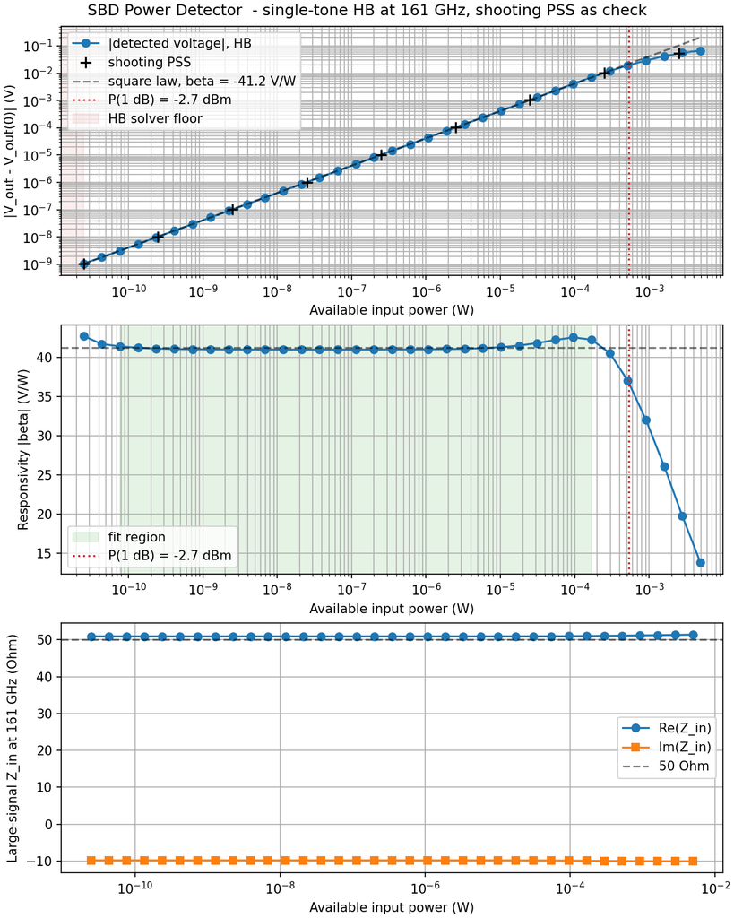

```python
RUN_PD_PSS = 1  # 1 = run this simulation, 0 = skip it

if RUN_PD_PSS:
    run_testbench("sparx_powdet_sbd_tb_pss_vacask")
    show_figure("sparx_powdet_sbd_pss_sweep.png")
```

**Transfer Curve Result:**

| quantity | value |
| --- | --- |
| responsivity | 41.2 V/W, flat from -71 dBm to -8 dBm |
| 1 dB compression point | -2.7 dBm |
| input impedance at 161 GHz | 50.9 - j9.8 Ohm, 51.4 - j10.0 Ohm at +6.9 dBm |
| shooting PSS against HB | within 0.6 % from -66 dBm to +4 dBm, 1.2 % at -76 dBm |

The detected voltage follows the square law, proportional to the input power, up to the compression point, and the input match stays flat up to there. How much of the input the diode converts is stated by the coupling efficiency

$$\eta = \frac{\beta / R_2}{\beta_{I,\mathrm{max}}}, \qquad \beta_{I,\mathrm{max}} = \frac{1}{2 n V_\mathrm{T}} = 18.29\ \mathrm{A/W},$$

the current responsivity $\beta / R_2$ of the detector, with the feedback resistor $R_2 = 911\ \Omega$ of the transimpedance amplifier, relative to that of an ideal square-law junction with ideality factor $n = 1.057$ and thermal voltage $V_\mathrm{T} = 25.86$ mV. It is only 0.25 % for the fabricated design. The Schottky unit cell has a series resistance of 1.36 kOhm against a junction resistance of 0.9 kOhm at its 30 uA bias, so the 52 Ohm termination, which gives the flat match, passes only about 2 % of the input power into the diode branch, and the series resistance and the junction capacitance of the cell take most of that at 161 GHz. This is the headline result of this block, see [section 3.2 of the testbench README](https://github.com/iic-jku/SG13CMOS_SPARX/blob/next_release/testbenches/xschem/README.md#32-transfer-curve-and-input-impedance).

**Power Detector: Noise Figure, NEP, and Minimum Detectable Power (HBAC, HBNOISE, PAC, and PNOISE):**

With the LO applied, the detector works as a mixer: an RF signal offset from the LO appears at the output at the difference frequency, the IF. Its noise figure needs two analyses around the large-signal LO solution. HBAC gives the conversion gain from the upper and the lower sideband to the IF, and HBNOISE the output noise with the LO on. HBNOISE evaluates every noise source at the pumped operating point and folds the noise at all LO harmonics down to the IF, which a small-signal noise analysis at the DC operating point cannot do. That analysis, the small-signal noise at the dc operating point with the LO off, is kept as the reference, since the noise figure rested on it before VACASK had HBNOISE. A second pair of HBAC and HBNOISE sweeps the LO power at a 2 GHz IF.

The same conversion and pumped noise are computed a second time around the periodic steady state of the LO found by shooting (PSS), a large-signal solution that shares no code with harmonic balance: PAC is the counterpart of HBAC, and PNOISE of HBNOISE, at the fixed LO and against the LO drive.

With the transducer conversion gain $g = |V_\mathrm{IF}|^2 / (2 P_\mathrm{RF})$ in V²/W of the upper and the lower sideband from HBAC and the output noise density $S_v$ at the IF, the double-sideband noise figure is

$$F_\mathrm{DSB} = 1 + \frac{S_v(f_\mathrm{IF})}{(g_\mathrm{U} + g_\mathrm{L})\, k T_0},$$

with the Boltzmann constant $k$ and the reference temperature $T_0 = 290$ K. Both sidebands carry signal in a six-port, so the double-sideband definition applies. Without an LO, the detector is characterized by its noise-equivalent power, the input power that gives a signal-to-noise ratio of one in a 1 Hz bandwidth,

$$\mathrm{NEP}(f) = \frac{\sqrt{S_v(f)}}{\beta\, |H(f)|},$$

with the responsivity $\beta$ of the previous cell and the normalized video response $|H(f)|$ from HBAC.

The figure shows the output noise density with its largest contributors (top left), the conversion of both sidebands to the IF (top right), and the double-sideband noise figure against the IF (bottom left) and against the LO power at a 2 GHz IF (bottom right). The open circles are the PAC and PNOISE results of the shooting cross-check.

> **Runtime:** On the two vCPUs of the free Colab tier, this cell takes about **1 minute**.

```
sparx_powdet_sbd_tb_nf_vacask: VACASK finished in 1.0 min
```

```
Variant               : as fabricated
LO                    : 159.0 GHz at -6.5 dBm available
Responsivity beta     : 41.22 V/W  (small signal, from the PSS testbench)
Conversion g at LO    : 0.6695 V^2/W at low IF from hbac, closed form 2 S'^2 P_lo = 0.6502 V^2/W (S' = 38.01 V/W), hbac - closed form = +0.13 dB
hbnoise gain vs hbac  : within 0.0000 dB over the IF sweep, 0.0048 dB over the LO sweep
IF output at -46.5 dBm RF: 173.6 uV at low IF, 61.2 uV at 2 GHz
Video bandwidth       : 1.24 GHz (-3 dB of the conversion, interpolated)
Sideband imbalance    : g_L/g_U = +0.02 dB at 2 GHz
Video band 1e+03 .. 5e+09 Hz :  1305.6 uV RMS, MDS  -15.0 dBm  (without PCell PNP:  -23.7 dBm)
Video band 1e+06 .. 5e+09 Hz :   905.3 uV RMS, MDS  -16.6 dBm  (without PCell PNP:  -23.9 dBm)

Output noise, pumped (hbnoise, LO on) against the small-signal noise at the dc operating
point (noise, LO off), and the noise figure from each. The pumped column is the result,
the other one is what the bench reported before hbnoise existed.
      f_IF  ASD pumped  ASD quiesc    p/q   NF_DSB  NF_DSB q   NF_SSB NF no PNP   beta(f)         NEP  NEP no PNP
      [Hz]    [V/rtHz]    [V/rtHz]            [dB]      [dB]     [dB]      [dB]     [V/W]    [W/rtHz]    [W/rtHz]
 1.000e+03   1.379e-05   1.131e-05   1.49   105.50    103.78   108.51     78.23      41.2   2.744e-07   1.493e-08
 9.996e+03   4.361e-06   3.577e-06   1.49    95.50     93.78    98.51     68.23      41.2   8.678e-08   4.724e-09
 9.993e+04   1.379e-06   1.131e-06   1.49    85.50     83.78    88.51     58.28      41.2   2.745e-08   1.501e-09
 9.989e+05   4.363e-07   3.578e-07   1.49    75.50     73.78    78.51     48.68      41.2   8.682e-09   4.958e-10
 9.986e+06   1.380e-07   1.132e-07   1.49    65.52     63.80    68.53     41.41      41.2   2.750e-09   2.119e-10
 9.982e+07   4.262e-08   3.388e-08   1.58    55.11     53.12    58.13     37.69      42.1   8.047e-10   1.353e-10
 5.002e+08   1.812e-08   1.360e-08   1.78    47.49     44.99    50.50     35.05      43.1   3.156e-10   9.762e-11
 9.979e+08   1.077e-08   7.988e-09   1.82    44.68     42.08    47.69     34.90      35.4   2.259e-10   9.387e-11
 1.991e+09   3.359e-09   2.606e-09   1.66    42.20     40.00    45.23     35.21      14.7   1.779e-10   9.872e-11
 5.000e+09   4.596e-10   3.985e-10   1.33    40.28     39.04    43.32     37.07       2.5   1.596e-10   1.258e-10

Noise figure against LO drive at 2 GHz IF:
  pumped noise   : best 42.3 dB at -6.3 dBm LO, 42.4 dB at the -6.5 dBm used here
  dc op. noise   : best 37.5 dB at 6.9 dBm LO, 40.1 dB at the -6.5 dBm used here
 P_LO [dBm]  S_int pumped  pumped/quiesc   NF_DSB  NF_DSB q
      -56.0     6.666e-18           0.98    88.58     88.66
      -52.7     6.666e-18           0.98    85.27     85.35
      -49.4     6.666e-18           0.98    81.96     82.04
      -46.1     6.666e-18           0.98    78.65     78.73
      -42.8     6.667e-18           0.98    75.34     75.42
      -39.5     6.669e-18           0.98    72.03     72.11
      -36.2     6.672e-18           0.98    68.72     68.79
      -32.8     6.680e-18           0.98    65.41     65.48
      -29.5     6.695e-18           0.99    62.10     62.16
```

[output cut: 15 more lines]

```
  pnoise gain vs pac     : within 5.2e-13 dB
  NF_DSB at 2 GHz        : 42.28 dB from pnoise, 42.20 dB from hbnoise
  against LO drive       : pnoise - HB conversion -0.041 .. +0.011 dB, NF -0.073 .. +0.099 dB, best NF 42.3 dB at -6.3 dBm

Top output-noise contributors over 1e+06 .. 5e+09 Hz, pumped, and their pumped-over-quiescent ratio:
  n(xdemod1:XD1:q1)                                 86.70 %   x1.84
  n(xdemod1:XD2:q1)                                 10.99 %   x0.76
  n(xdemod1:XR2:nr1)                                 1.31 %   x1.05
  n(xdemod1:XD1:rsmain)                              0.24 %   x0.91
  n(xdemod1:XR4:nr1)                                 0.20 %   x1.03
  n(xdemod1:XD1:dmain)                               0.19 %   x1.99

Wrote /tmp/sparx/testbenches/xschem/plot_simulations/data/sparx_powdet_sbd_nf.json
Wrote /tmp/sparx/testbenches/xschem/plot_simulations/data/sparx_powdet_sbd_nf.csv
Wrote /tmp/sparx/testbenches/xschem/plot_simulations/data/sparx_powdet_sbd_nf_lo.csv
```

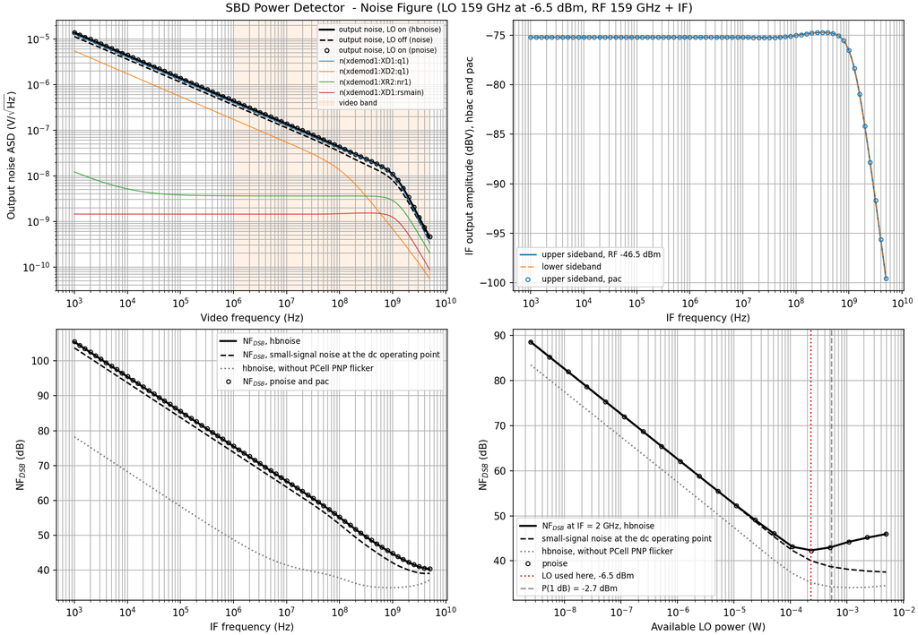

```python
RUN_PD_NF = 1  # 1 = run this simulation, 0 = skip it

if RUN_PD_NF:
    run_testbench("sparx_powdet_sbd_tb_nf_vacask")
    show_figure("sparx_powdet_sbd_nf.png")
```

**Noise Figure Result:**

At a 2 GHz IF and -6.5 dBm of LO, the drive each detector sees in the receiver:

| quantity | value |
| --- | --- |
| noise figure, double sideband, HBNOISE | 42.2 dB |
| noise figure, double sideband, PNOISE with PAC (shooting cross-check) | 42.3 dB |
| noise figure, double sideband, small-signal noise at the dc operating point | 40.0 dB |
| best noise figure against the LO drive, HBNOISE | 42.3 dB at -6.3 dBm |
| output noise with the LO on over the LO off | 1.66 (1.5 at low IF, 1.8 near 1 GHz) |
| video bandwidth | 1.24 GHz |
| NEP | 8.7 nW/sqrt(Hz) at 1 MHz, 226 pW/sqrt(Hz) at 1 GHz |
| minimum detectable power, 1 MHz to 5 GHz | -16.6 dBm |

**Power Detector: Transient Noise:**

Transient noise solves the circuit in the time domain with random noise sources and shares no code path with HBNOISE, so it is the independent check of the linearization around the pumped LO solution. Three 100 ns transients with the LO on at -6.5 dBm differ only in the noise amplitude (`noisescale` 0.01, 0.0316, and 0.1). The output spectrum of each run is split into a term linear in the noise power and a remainder, and the linear term is compared against HBNOISE, PNOISE, and the small-signal noise at the dc operating point of the previous cell. The noise amplitude has to stay this small: at full amplitude, the transient noise of this stiff, strongly nonlinear circuit produces a numerical excess that is not physical.

The first figure shows the output noise of the three runs normalized by their noise amplitude, which collapse onto one curve if the circuit responds linearly, together with the linear term and the excess. The second figure compares the noise figure from four noise estimates: transient noise, HBNOISE, PNOISE, and the small-signal noise at the dc operating point.

> **Runtime:** On the two vCPUs of the free Colab tier, this cell takes about **6 minutes**.

```
sparx_powdet_sbd_tb_tn_vacask: VACASK finished in 5.0 min
```

```
LO                    : on, 300 mV, reference is hbnoise, LO on
Records               : 600001 points, fs = 6.667e+12 Hz, 17 Welch segments, df = 1.017e+08 Hz
noisescale points     : 0.01, 0.0316228, 0.1

  f [Hz]  linear ASD  hbnoise, LO on  ratio noise, LO off  ratio top rung/ns  excess
            [V/rtHz]        [V/rtHz]             [V/rtHz]           [V/rtHz]     [x]
 5.0e+08   1.756e-08       1.813e-08  0.969     1.360e-08  1.291   1.760e-08    1.00
 1.0e+09   1.190e-08       1.075e-08  1.108     7.971e-09  1.493   1.240e-08    1.04
 2.0e+09   3.913e-09       3.334e-09  1.173     2.587e-09  1.512   3.803e-09    0.97
 3.0e+09   1.532e-09       1.397e-09  1.097     1.132e-09  1.353   1.458e-09    0.95

"ratio" is the linear term of the transient-noise split against the small-signal
reference and should be near 1. "excess" is what the top rung, normalised by its
noisescale, reports on top of it.
It is not physical rectified noise, see the header, and it depends on the noise
settings. Do not quote it.

Normalised ASD per rung, sqrt(S)/noisescale at 1 GHz. A purely linear circuit
gives one value on every rung:
  noisescale 0.01   1.191e-08 V/rtHz
  noisescale 0.0316228 1.202e-08 V/rtHz
  noisescale 0.1    1.240e-08 V/rtHz

Order of the excess between the middle and top rungs, from S - a*x at each.
Rectified Gaussian noise is exactly 2. Anything well above 2 is not rectification.
  from noisescale 0.0316228 to 0.1:   0.5 GHz n/a (no excess at the middle rung)   1.0 GHz 1.6   2.0 GHz n/a (no excess at the middle rung)   3.0 GHz n/a (no excess at the middle rung)

Double-sideband noise figure at 0.225 mW LO from the noise
estimates, with the hbac conversion of the NF testbench in the denominator. The
transient value uses the linear term of the ladder less the source resistor share
of the hbnoise result.
 f_IF [Hz]  transient   hbnoise  quiescent   pnoise
   5.0e+08      47.21     47.49      44.99    47.58
   1.0e+09      45.56     44.67      42.08    44.76
   2.0e+09      43.58     42.19      39.99    42.27
   3.0e+09      41.88     41.05      39.24    41.12

Wrote /tmp/sparx/testbenches/xschem/plot_simulations/figures/sparx_powdet_sbd_tn.png
Wrote /tmp/sparx/testbenches/xschem/plot_simulations/figures/sparx_powdet_sbd_nf_compare.png
Wrote /tmp/sparx/testbenches/xschem/plot_simulations/data/sparx_powdet_sbd_nf_compare.csv
Wrote /tmp/sparx/testbenches/xschem/plot_simulations/data/sparx_powdet_sbd_tn.json
Wrote /tmp/sparx/testbenches/xschem/plot_simulations/data/sparx_powdet_sbd_tn.csv
```

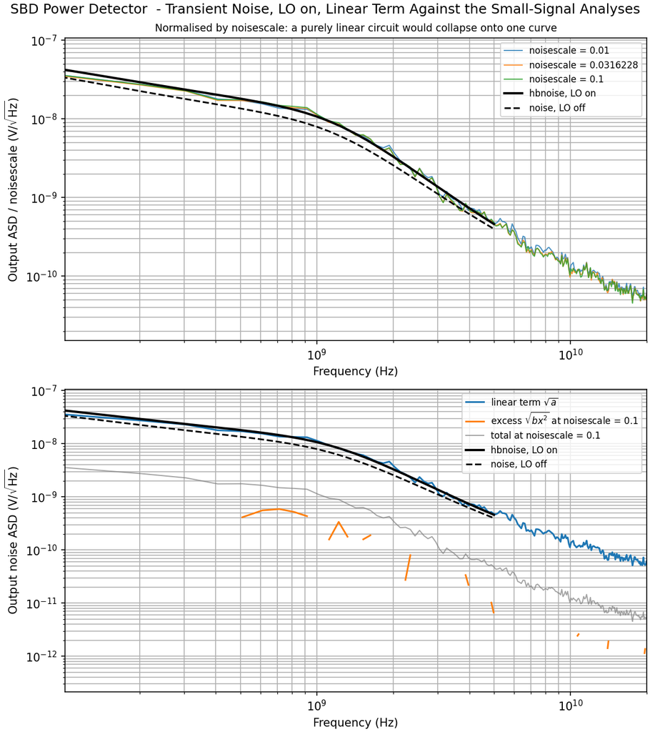

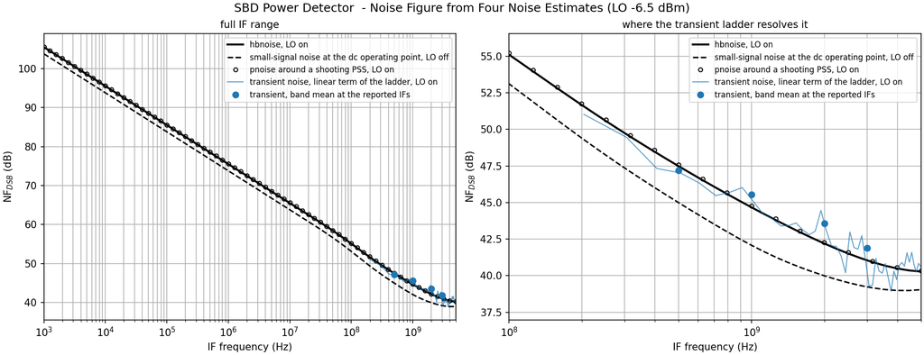

```python
RUN_PD_TN = 1  # 1 = run this simulation, 0 = skip it

if RUN_PD_TN:
    if not os.path.exists(f"{SIM_DIR}/powdet_nf_hbnoise_usb.raw"):
        print("The transient-noise simulation needs the result of the noise-figure simulation, run that cell first.")
    else:
        run_testbench("sparx_powdet_sbd_tb_tn_vacask")
        show_figure("sparx_powdet_sbd_tn.png")
        show_figure("sparx_powdet_sbd_nf_compare.png")
```

**Transient Noise Result:**

Double-sideband noise figure of one run of this notebook on VACASK `fb8cc20`, with the HBAC conversion of the noise-figure simulation in the denominator:

| IF | transient noise | HBNOISE | PNOISE | small-signal noise at the dc operating point |
| --- | --- | --- | --- | --- |
| 0.5 GHz | 47.2 dB | 47.5 dB | 47.6 dB | 45.0 dB |
| 1 GHz | 45.6 dB | 44.7 dB | 44.8 dB | 42.1 dB |
| 2 GHz | 43.6 dB | 42.2 dB | 42.3 dB | 40.0 dB |
| 3 GHz | 41.9 dB | 41.1 dB | 41.1 dB | 39.2 dB |

The three runs collapse onto one curve within 5 % when normalized by their noise amplitude, so the transient is in its linear regime. It lies within 1.4 dB of HBNOISE and 2.2 dB to 3.6 dB above the small-signal noise at the dc operating point, with the same frequency dependence. PNOISE around the shooting PSS sits within 0.1 dB of HBNOISE, so the offset of the transient belongs to the transient estimate and not to the periodic analyses. Transient noise is a random process, and a noise figure from a 100 ns record is good to about 1 dB: [section 3.4 of the testbench README](https://github.com/iic-jku/SG13CMOS_SPARX/blob/next_release/testbenches/xschem/README.md#34-transient-noise-the-independent-check-of-hbnoise) lists three noise seeds. The same seed draws another realization on `fb8cc20` than on VACASK `1b48553`, on which the result of the repository was produced: 45.4 dB, 43.0 dB, and 41.3 dB at 1 GHz, 2 GHz, and 3 GHz, while HBNOISE, PNOISE, and the small-signal noise are the same on both builds. The reference result of the repository:

[figure not shown]

The repository runs the same comparison against the LO drive at a 2 GHz IF, with a transient-noise ladder at nine LO levels (`sparx_powdet_sbd_tb_tn_lo_vacask`, about 24 minutes, not part of this notebook). PNOISE stays within 0.1 dB of HBNOISE over the whole LO sweep, and the transient lies 0.6 dB to 1.1 dB above them and follows their rise past compression. The small-signal noise at the dc operating point leaves the three above about -16 dBm and keeps falling, so it is 8.4 dB optimistic at +6.9 dBm, see [section 3.5 of the testbench README](https://github.com/iic-jku/SG13CMOS_SPARX/blob/next_release/testbenches/xschem/README.md#35-noise-figure-against-lo-drive-from-four-noise-estimates):

[figure not shown]

**Receiver: Six-Port Core with Post-Layout Power Detectors (HB, HBAC, and Transient):**

The receiver testbench combines the snp2le fit of the six-port core with the four power detectors, each replaced by its post-layout extraction with `powdet_variant.py`, as `make sim-xschem VARIANT=m1_pex` does in the repository, and each output loaded with 5 pF off-chip. The LO at 159 GHz and +12 dBm and the RF at 161 GHz and -20 dBm are applied at the pads through 50 Ohm. One testbench runs all analyses:

- HB with the RF alone and with the LO alone gives the loss of the RF and LO paths from the pads to each detector, and the drive each detector sees.
- HBAC gives the IF response of the four outputs from 1 MHz to 5 GHz, and the IF output at 2 GHz against the LO power at the pad.
- A two-tone HB at the levels of the transient is an independent cross-check.
- A 10 ns transient gives the output waveforms at the 2 GHz IF. It runs this long because the detected DC needs about that time to settle.

The figure shows the last nanosecond of the four differential outputs, with the 2 GHz IF and a small carrier feed-through riding on it (top), the IF output at 2 GHz against the LO power (middle), and the IF response of the four outputs (bottom).

> **Runtime:** On the two vCPUs of the free Colab tier, this cell takes about **15 minutes**.

```
/tmp/sparx/testbenches/xschem/simulations/m1_pex/sparx_top_le_tb_rx_vacask.spectre: subckt sparx_powdet_sbd replaced by the Magic full-RC extraction: 116 devices, 70 resistors, 113 capacitors, 157 elements inside the idealized nets ['vss'] dropped, 5 capacitor-only nodes tied to ground through 1 TOh…
```

```
sparx_top_le_tb_rx_vacask: VACASK finished in 10.8 min
```

```
Variant             : m1_pex
Detector Z_in       : 40.3 -25.0j Ohm at 161 GHz (PSS bench)
RF at the pad       : -20.0 dBm available (63.2 mV behind 50 Ohm), 161 GHz, LO off
RF at the detectors (HB fundamental at the detector input):
   detector 1:   12.32 mV,  -28.7 dBm, loss from the pad   8.7 dB
   detector 2:   11.51 mV,  -29.3 dBm, loss from the pad   9.3 dB
   detector 3:   17.86 mV,  -25.4 dBm, loss from the pad   5.4 dB
   detector 4:   11.83 mV,  -29.0 dBm, loss from the pad   9.0 dB
LO at the pad       : +12.0 dBm available (2.52 V behind 50 Ohm), 159 GHz
LO at the detectors (HB fundamental at the detector input):
   detector 1:   155.7 mV,   -6.6 dBm, loss from the pad  18.6 dB
   detector 2:   181.2 mV,   -5.3 dBm, loss from the pad  17.3 dB
   detector 3:   165.8 mV,   -6.1 dBm, loss from the pad  18.1 dB
   detector 4:   178.5 mV,   -5.4 dBm, loss from the pad  17.5 dB
RF at the pad       : -20.0 dBm available, IF 2 GHz
IF output of the four detectors at that RF:
   out1:   1347.2 uV at 1 MHz,    364.6 uV at 2 GHz, -3 dB at 1.00 GHz
   out2:   1376.7 uV at 1 MHz,    368.0 uV at 2 GHz, -3 dB at 1.00 GHz
   out3:   2049.5 uV at 1 MHz,    546.7 uV at 2 GHz, -3 dB at 1.00 GHz
   out4:   1398.6 uV at 1 MHz,    375.0 uV at 2 GHz, -3 dB at 1.00 GHz
Six-port at +12.1 dBm LO, 2 GHz IF: phases relative to out1 out1 +0 deg, out2 +162 deg, out3 -102 deg, out4 +96 deg; pairs (out1, out2) and (out3, out4); I/Q amplitude ratio -2.0 dB, angle between I and Q -85.6 deg
   at +3.0 dBm LO at the pad: IF 146 uV, 159 uV, 226 uV, 161 uV
   at +12.0 dBm LO at the pad: IF 361 uV, 365 uV, 541 uV, 371 uV
Two-tone HB at +12.0 dBm LO, -20.0 dBm RF: IF 359 uV, 362 uV, 546 uV, 395 uV; against hbac -0.12 dB, -0.13 dB, +0.00 dB, +0.47 dB
Transient, last nanosecond: 2 GHz fundamental of the four differential outputs 358 uV, 361 uV, 537 uV, 368 uV; against hbac -0.16 dB, -0.15 dB, -0.14 dB, -0.14 dB (dc -16.62 mV, -19.52 mV, -17.79 mV, -19.21 mV)
Wrote /tmp/sparx/testbenches/xschem/plot_simulations/figures/sparx_top_le_rx_m1_pex.png and the CSV/JSON files in /tmp/sparx/testbenches/xschem/plot_simulations/data
```

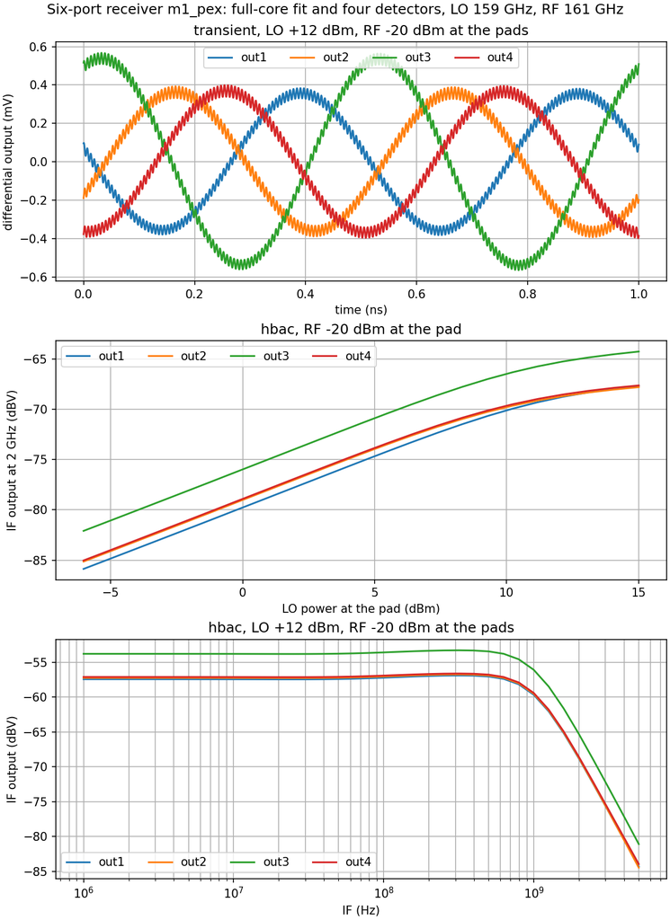

```python
RUN_RX = 1  # 1 = run this simulation, 0 = skip it

if RUN_RX:
    # the schematic detector subcircuit is replaced by the Magic full-RC extraction
    ! mkdir -p {SIM_DIR}/m1_pex && cp {SIM_DIR}/sparx_top_le_tb_rx_vacask.save {SIM_DIR}/m1_pex/
    ! python3 {SPARX_DIR}/scripts/powdet_variant.py --variant m1_pex {SIM_DIR}/sparx_top_le_tb_rx_vacask.spectre {SIM_DIR}/m1_pex/sparx_top_le_tb_rx_vacask.spectre
    run_testbench("sparx_top_le_tb_rx_vacask", "m1_pex")
    show_figure("sparx_top_le_rx_m1_pex.png")
```

**Receiver Result:**

| quantity | value |
| --- | --- |
| LO path loss, pad to detector | 17.3 dB to 18.6 dB |
| LO power at the detectors | -6.6 dBm to -5.3 dBm |
| RF path loss, pad to detector | 5.4 dB to 9.3 dB |
| I/Q amplitude imbalance | 2.0 dB |
| I/Q phase difference | 85.4 degrees in the transient, 85.6 degrees from HBAC |
| transient against HBAC | within 0.2 dB |
| two-tone HB against HBAC | within 0.5 dB |

- The LO path through filter, divider, and coupler places each detector at the operating point the detector was characterized at above. The losses are into the post-layout detectors, whose input impedance differs from 50 Ohm, so they differ from the 50 Ohm insertion loss of the EM solve by up to about 2 dB per output.
- The amplitude and phase imbalance of the differential I and Q outputs is absorbed by the six-port calibration. The EM data alone predict it within 0.1 dB and 0.1 degree: terminating the EM core on its four detector ports with the post-layout detector impedance, 40.3 - j25.0 Ohm at 161 GHz, and forming the product of the conjugated LO-path and the RF-path waves per output gives 2.1 dB and 85.3 degrees. The circuit simulation and the EM solve agree without any fitting. With 50 Ohm on every port the EM gives 2.5 dB and 84.5 degrees, so that difference is the mismatch of the detectors, which also makes $V_{Q-}$ the largest of the four outputs.
- The noise figure of the receiver is simulated in the next cell, through the core fit and its thermal noise. [Section 4.1 of the testbench README](https://github.com/iic-jku/SG13CMOS_SPARX/blob/next_release/testbenches/xschem/README.md#41-receiver-characterization) describes this testbench in detail.

The reference result of the repository:

[figure not shown]

**Receiver: Noise Figure through the Noisy Core Model (HBAC, HBNOISE, PAC, and PNOISE):**

The receiver noise figure used to be stated as a composition, the detector noise figure plus the RF path loss, because the fitted core had no noise of its own. With the thermal noise of the core in the snp2le fit, this testbench simulates it: the four detectors pumped through the fitted LO path, the RF reaching them through the fitted RF path, and the detectors loading the core with their own input impedance. The LO is at 159 GHz and +12 dBm at the pad, as in the receiver testbench, and the RF is a small signal at both sidebands of the LO. Six outputs are evaluated, the four differential detector outputs out1 to out4 ($V_{I-}$, $V_{I+}$, $V_{Q-}$, $V_{Q+}$) and the six-port outputs $I$ = out2 - out1 and $Q$ = out4 - out3, which every noise analysis takes as a node pair. The double-sideband noise figure is that of the detector, referred to the RF pad, with the noise of the 50 Ohm RF source removed from the numerator. Per output, the testbench runs:

- the small-signal noise at the dc operating point, with the LO off,
- HBAC for both sidebands and HBNOISE around the HB solution of the LO at 15 harmonics,
- PAC for both sidebands and PNOISE around the shooting PSS of the same LO,
- HBAC and HBNOISE at a 2 GHz IF against the LO power at the pad, from -6 dBm to +18 dBm, and PNOISE of $I$ and $Q$ at five of these levels.

The shooting PSS of the fitted core needs a first stabilization step of 20 fs or more, and the testbench uses `stabstep=50f`. At the default of a thousandth of the LO period, the stabilization transient aborts. The detectors run as fabricated, since with their post-layout extraction the testbench takes about 2.5 hours of CPU time.

The figure shows the noise figure of $I$ and $Q$ over the IF with the PNOISE cross-check as open circles (top left), that of the four detector outputs with the composition of the detector noise figure and the RF path loss as crosses (top right), the IF conversion from HBAC with the PAC cross-check (bottom left), and the noise figure at a 2 GHz IF against the LO power at the pad (bottom right).

> **Runtime:** This cell takes 31 minutes on a laptop with an Intel Core Ultra 7 255U, and an estimated **45 minutes** on the two vCPUs of the free Colab tier.

```
sparx_top_le_tb_nf_vacask: VACASK finished in 36.4 min
```

```
Variant              : as fabricated
LO                   : 159 GHz at +12.0 dBm available at the pad
Core thermal noise   : 2.1e-05 to 3.3e-05 of the output noise, 0.00009 to 0.00014 dB of NF_DSB at 2 GHz (hbnoise), from the Rnz_e* sources only

At 2 GHz IF, NF_DSB referred to the RF pad:
          output      g_U  hbnoise  pnoise   dc op  no PNP LO on/off      Rrf      Rlo       R4
                 [dBV2/W]     [dB]    [dB]    [dB]    [dB]              share    share    share
            out1   -18.78    50.29   50.34   48.13   43.34      1.65  9.9e-06  8.2e-07  1.1e-05
            out2   -19.87    52.64   52.59   49.35   44.73      2.13  5.8e-06  1.2e-06  6.8e-06
            out3   -16.54    48.28   48.31   45.82   41.08      1.76  1.6e-05  9.2e-07  7.3e-06
            out4   -17.78    50.29   50.24   47.05   42.43      2.11  9.9e-06  1.1e-06  4.4e-06
               i   -13.34    48.52   48.51   45.76   41.05      1.89  1.5e-05  4.5e-08  1.7e-05
               q   -11.13    46.28   46.27   43.42   38.74      1.94  2.4e-05  2.1e-08  1.1e-05

 f_IF [Hz]     i hbn     i dc     q hbn     q dc
   1.0e+06     81.78    79.52     79.55    77.20
   1.0e+08     61.42    58.85     59.21    56.54
   5.0e+08     53.87    50.73     51.66    48.42
   1.0e+09     51.03    47.81     48.82    45.48
   2.0e+09     48.52    45.76     46.28    43.42
   5.0e+09     46.55    44.94     44.20    42.53

Shooting cross-check, pac against hbac and pnoise against hbnoise, over the IF sweep:
   out1: pac - hbac -0.007 .. -0.006 dB, pnoise - hbnoise +0.024 .. +0.048 dB, pnoise gain vs pac 1.0e-13 dB
   out2: pac - hbac -0.005 .. -0.004 dB, pnoise - hbnoise -0.062 .. -0.033 dB, pnoise gain vs pac 1.7e-12 dB
   out3: pac - hbac -0.006 .. -0.006 dB, pnoise - hbnoise +0.017 .. +0.036 dB, pnoise gain vs pac 4.9e-13 dB
   out4: pac - hbac -0.005 .. -0.005 dB, pnoise - hbnoise -0.066 .. -0.038 dB, pnoise gain vs pac 1.8e-12 dB
      i: pac - hbac -0.006 .. -0.005 dB, pnoise - hbnoise -0.015 .. -0.007 dB, pnoise gain vs pac 8.3e-13 dB
      q: pac - hbac -0.006 .. -0.005 dB, pnoise - hbnoise -0.020 .. -0.012 dB, pnoise gain vs pac 7.3e-13 dB
hbnoise gain vs hbac : within 2.5e-14 dB over the IF sweep, 3.1e-03 dB over the LO sweep

Correlation          : S_I / (S_out1 + S_out2) = 1.0000, S_Q / (S_out3 + S_out4) = 1.0000 at 2 GHz (hbnoise)
LO source noise      : 13.5 dB below the sum of its two detectors in I, 17.0 dB in Q
Composition at 2 GHz  : detector NF bench at the LO each detector sees, both referred to delivered power (-0.04 dB of mismatch), plus its RF path loss
  out1: 42.36 dB at -6.6 dBm LO + 7.98 dB = 50.33 dB, receiver 50.29 dB, difference -0.04 dB
  out2: 42.59 dB at -4.8 dBm LO + 9.92 dB = 52.51 dB, receiver 52.64 dB, difference +0.12 dB
  out3: 42.35 dB at -6.1 dBm LO + 6.02 dB = 48.36 dB, receiver 48.28 dB, difference -0.09 dB
  out4: 42.57 dB at -4.9 dBm LO + 7.78 dB = 50.35 dB, receiver 50.29 dB, difference -0.06 dB

NF_DSB at 2 GHz against the LO power at the pad (hbnoise, pnoise where run):
```

[output cut: 17 more lines]

```

Largest output-noise contributors of the I output at 2 GHz, pumped:
  n(x1:x2:XD1:q1)                           47.11 %
  n(x1:x1:XD1:q1)                           34.57 %
  n(x1:x2:XR2:nr1)                           5.64 %
  n(x1:x1:XR2:nr1)                           5.59 %
  n(x1:x2:XD1:dmain)                         1.09 %
  n(x1:x2:XD1:rsmain)                        1.04 %
  n(x1:x1:XD1:rsmain)                        1.03 %
  n(x1:x1:XD1:dmain)                         0.81 %

Wrote /tmp/sparx/testbenches/xschem/plot_simulations/figures/sparx_top_le_nf.png
Wrote /tmp/sparx/testbenches/xschem/plot_simulations/data/sparx_top_le_nf.json
Wrote /tmp/sparx/testbenches/xschem/plot_simulations/data/sparx_top_le_nf.csv
Wrote /tmp/sparx/testbenches/xschem/plot_simulations/data/sparx_top_le_nf_lo.csv
```

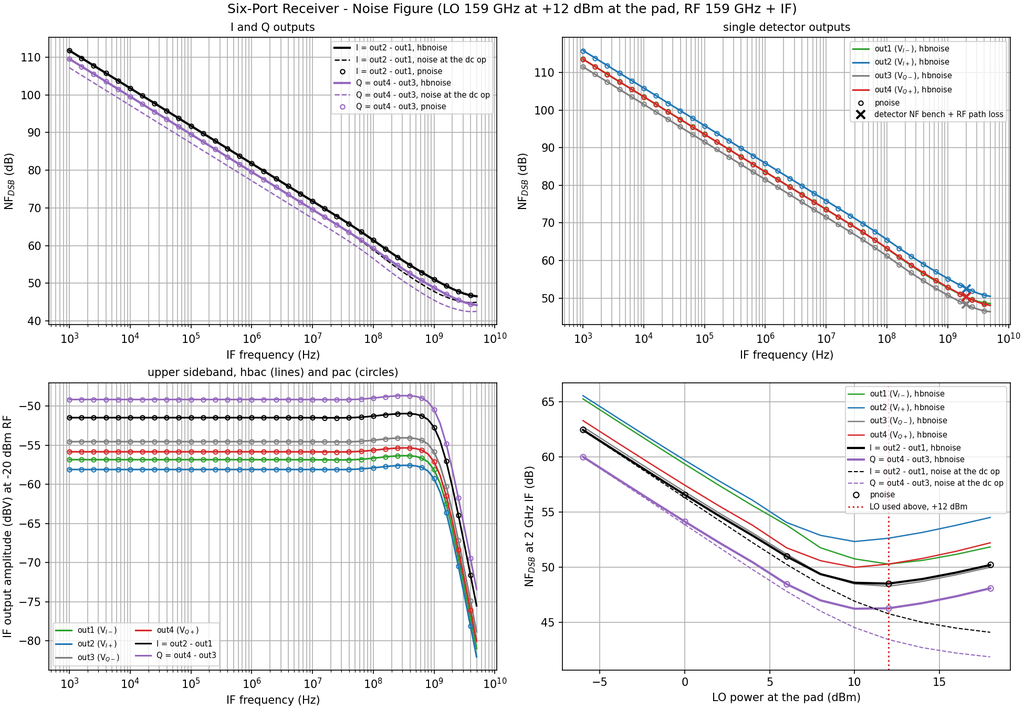

```python
RUN_RX_NF = 1  # 1 = run this simulation, 0 = skip it

if RUN_RX_NF:
    run_testbench("sparx_top_le_tb_nf_vacask")
    show_figure("sparx_top_le_nf.png")
```

**Receiver Noise Figure Result:**

Double-sideband noise figure referred to the RF pad, at a 2 GHz IF and +12 dBm of LO at the pad:

| output | HBNOISE | PNOISE | small-signal noise at the dc operating point | post-layout, HBNOISE |
| --- | --- | --- | --- | --- |
| out1 ($V_{I-}$) | 50.3 dB | 50.3 dB | 48.1 dB | 51.3 dB |
| out2 ($V_{I+}$) | 52.6 dB | 52.6 dB | 49.3 dB | 51.6 dB |
| out3 ($V_{Q-}$) | 48.3 dB | 48.3 dB | 45.8 dB | 47.8 dB |
| out4 ($V_{Q+}$) | 50.3 dB | 50.2 dB | 47.1 dB | 51.4 dB |
| $I$ | 48.5 dB | 48.5 dB | 45.8 dB | 48.5 dB |
| $Q$ | 46.3 dB | 46.3 dB | 43.4 dB | 46.5 dB |

- **$I$ and $Q$ are better than either of their detectors**, by 1.8 dB and 2.0 dB. The two members of a pair sit about 180 degrees apart at the IF, so their signals add coherently in the difference while their noise adds in power.
- **The LO source noise cancels in $I$ and $Q$.** It reaches both detectors of a pair through the same LO path, and the difference holds it 13.5 dB ($I$) and 17.0 dB ($Q$) below the sum of the two single outputs. The thermal noise of the 50 Ohm LO source is negligible either way, but the mechanism rejects the AM noise of a real LO the same way.
- **The composition holds.** Each detector output equals the noise figure of the detector simulation above at the LO drive that detector sees, plus its RF path loss, within 0.12 dB as fabricated and 0.28 dB post-layout, once both are referred to the power delivered into the detector.
- **The core's own thermal noise adds 0.0001 dB.** The noise generator of the snp2le fit carries 2e-5 to 3e-5 of the output noise, because 6 dB to 10 dB of passive loss sits in front of detectors with a noise figure of 42 dB. The detector sets the noise floor of this receiver.
- **PNOISE confirms HBNOISE, and the small-signal estimate is optimistic again.** PAC agrees with HBAC within 0.007 dB and PNOISE with HBNOISE within 0.1 dB on all six outputs, while the small-signal noise at the dc operating point is 2.2 dB to 3.3 dB optimistic, as on the single detector.
- **The noise figure against the LO drive has its minimum at the operating point**, +10 dBm to +12 dBm at the pad. Below it, the noise figure falls by 1 dB per dB of LO, the square-law regime.

The transient-noise ladder of the detector, run on the receiver in the repository (`sparx_top_le_tb_tn_vacask`, about 30 minutes, not part of this notebook), is the fourth estimate. It lies -1.4 dB to +1.6 dB around HBNOISE on all six outputs, the realization scatter of a 100 ns record, see [section 4.2 of the testbench README](https://github.com/iic-jku/SG13CMOS_SPARX/blob/next_release/testbenches/xschem/README.md#42-receiver-noise-figure-from-four-noise-estimates). The reference results of the repository, the noise figure as fabricated and the comparison of the four noise estimates:

[figure not shown]

# Conclusion

This notebook generated SPARX, a mmWave six-port receiver in the 130-nm IHP-Open-PDK, entirely in Python and with open-source tools only:

- **Layout:** The complete chip, from the Schottky-diode power detector over the six-port network of branch-line couplers, Wilkinson power divider, and hairpin bandpass filter to pads, sealring, and metal fill, is derived from a single design frequency `f`. Changing it regenerates the full layout, as the video demonstrates from 60 GHz to 300 GHz. The 160 GHz version was taped out in March 2026.
- **Verification:** The generated layout passes the KLayout DRC of the IHP-Open-PDK. At the `regular` level, only the antenna violations that IHP waived for the tapeout remain.
- **EM to circuit:** snp2le turns the 7-port EM result of the six-port core into a passive lumped-element netlist, which reproduces the EM S-parameters at 160 GHz within 0.45 dB and 9.9 degrees, carries the thermal noise of the core by Bosma's theorem, and makes the passive network usable in harmonic balance, shooting, noise, and transient simulations.
- **Power detector:** HB and PSS give a responsivity of 41 V/W with a 1 dB compression point of -2.7 dBm. HBAC and HBNOISE give a double-sideband noise figure of 42 dB at a 2 GHz IF, dominated by the flicker noise of the parasitic PNP in the diode model. PAC and PNOISE around a shooting PSS confirm HBAC and HBNOISE within 0.1 dB, transient noise within about 1 dB, while the small-signal noise at the dc operating point is 2.3 dB optimistic at the operating point and 8.4 dB at +6.9 dBm of LO. A mixer noise figure needs a large-signal noise analysis.
- **Receiver:** With the post-layout detectors, the LO path places each detector at its characterized operating point, and the I/Q imbalance of 2.0 dB and 85.4 degrees agrees with the EM core loaded by the detectors, 2.1 dB and 85.3 degrees. The noise figure of the receiver, simulated through the noisy core model, is 48.5 dB at $I$ and 46.3 dB at $Q$ (46.5 dB post-layout), and the thermal noise of the core adds 0.0001 dB of it.

The frequency scaling rests on the closed-form models alone, without any tuning: the branch-line couplers and the Wilkinson power divider keep an input matching of -16 dB or better over the whole range from 60 GHz to 300 GHz, with a coupler amplitude imbalance of 1.2 dB to 1.8 dB.

**Outlook:** Silicon measurements of the 160 GHz chip are planned, followed by a revised design with 16 parallel Schottky cells per detector, which raises the responsivity from 41 V/W to 251 V/W, an optimized bandpass filter, and active RF blocks such as an LNA, an LO amplifier, and a VCO.

The complete design and verification flow, including the EM simulations with AWS Palace, LVS, and parasitic extraction, is available in the [SPARX repository](https://github.com/iic-jku/SG13CMOS_SPARX) and runs in the IIC-OSIC-TOOLS container. The [SPARX documentation](https://iic-jku.github.io/SG13CMOS_SPARX/) describes it with all results.

# Clean Up and Total Runtime

```python
! rm -rf {IHP_DIR} {PDK_ROOT} {ASSET_DIR} /tmp/klayout.deb {SPARX_DIR}


print(f"Total runtime: {(time.time() - NOTEBOOK_START) / 60:.1f} min")
```

```
Total runtime: 61.1 min
```